# Population ATAC

### Map of Mouse and Human $\alpha \beta$ T Cell Development (Actually only mouse in this assignment)

The data analyzed in this assignment was accompanied by the following paper: Chopp et al., An Integrated Epigenomic and Transcriptomic Map of Mouse and HumanabT Cell Development,Immunity (2020), https://doi.org/10.1016/j.immuni.2020.10.024

The publication contains several sequencing data sets, which are listed below:

- GSE148973 (RNAseq EXP1)
- GSE148974 (RNAseq Exp2)
- **GSE148975 (Population ATACseq)**
- GSE148976 (Thpok ChIPSeq)
- GSE148977 (Mouse scRNAseq)
- GSE148978 (Human scRNAseq)
- GSE148979 (Mouse scATACseq)
- GSE148980 (Human scATACseq)
- GSE157286 (ThpokKO scRNAseq)

In this assignment only the population ATAC sequencing data will be analyzed, printed in bold above and can be accessed here https://www.ncbi.nlm.nih.gov/geo/query/acc.cgi?acc=GSE148975 . In the screenshot below additional information on the individuals runs are listed, unfortunately no bigWig file or bed file is uploaded (yet). The publication is very recent.

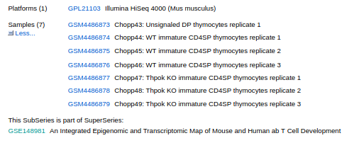

- Thpok KO immature CD4SP thymocytes
- WT immature CD4SP thymocytes
- Unsignaled DP thymocytes

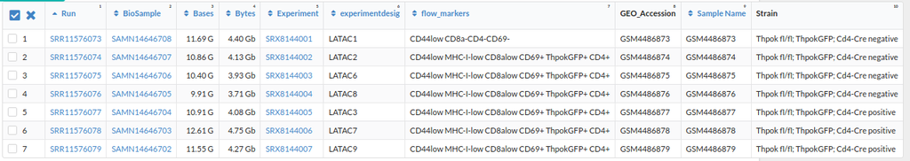

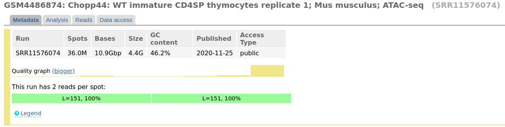

The population ATAC data is based on 50.000 cells per sample and sequenced on an Illumina HiSeq 4000 (150bp paired-end). Note that only the nuclei were isolated and so no mtDNA was extracted but apparently this is imperfect and samtool was used to remove mtDNA contamination.The followig analysis pipeline was outlined in the publication:

- ATACseq fastq files were trimmed with Trimmomatic
- Aligned to mouse genome (mm10) using Bowtie2 (v2.3.4,X set to 2000)
- Low quality (MAPQ < 30) and mitochondrial reads were removed with Samtools (v1.6)
- Peaks were called using Macs2 (v2.2.4, pvalue 1e-7 and–keep-dup all)
- Homer (4.10) for peak annotation and motif enrichment analyses

The paper is focussing mainly on the sincle cell data but one figure on the population ATAC sequencing at least made the supplementary material(S4D) as mentioned in the section on "**Genomic and Transcriptomic Impacts of Thpok during CD4+ T Cell Differentiation**":

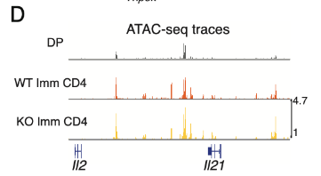

(D)Population ATAC-seq was performed on wild-type orZbtb7b-deficient immature CD4+ SP thymocytes sorted asin Fig.S4A,and unsignaled wild-type DP thymocytes(CD4+CD8+CD69–).Genome browser tracks show ATAC-seq signals at the Il2-Il21 gene locus.Representative of three biologicalreplicates per genotype.

One goal of this analasysis is to reproduce this figure and to try to add some more insight if time permits.

```bash
mkdir -p /mnt/storage/$USER/jupyternotebooks/Assignment2/Fastq
cd /mnt/storage/$USER/jupyternotebooks/Assignment2/Fastq
```

```bash
pwd
```

```
/mnt/storage/r0639760/jupyternotebooks/Assignment2/Fastq
```

```bash
#Test run
#START=11576073
#END=11576079


#for i in $(seq $START $END);
#do
#    fastq-dump --split-files -X 50 'SRR'"$i"
#done

#gave random errors for some runs, next try it gave the error on other runs
#but downloaded the ones that gave an error before; went ahead with using fasterq-dump instead
```

## Download fastq files

```bash
START=11576076
END=11576077

for i in $(seq $START $END);
do
    fasterq-dump 'SRR'"$i" -e 40; #use 40 threads, the server has 20 cores with 2 threads each
done
```

```bash
#check number of reads
START=11576076
END=11576077
for i in $(seq $START $END);
do
    for j in $(seq 1 2);
    do
        echo 'Number of reads for SRR'"$i"'_'"$j"'.fastq : ' | tr -d "\n";
        grep @ 'SRR'"$i"'_'"$j"'.fastq' |wc -l;
    done
done
#Save output below since files will be removed in next box
#Number of reads for SRR11576076_1.fastq : 32819161
#Number of reads for SRR11576076_2.fastq : 32819161
#Number of reads for SRR11576077_1.fastq : 36125238
#Number of reads for SRR11576077_2.fastq : 36125238
```

```
Number of reads for SRR11576076_1.fastq : grep: SRR11576076_1.fastq: No such file or directory
0
Number of reads for SRR11576076_2.fastq : grep: SRR11576076_2.fastq: No such file or directory
0
Number of reads for SRR11576077_1.fastq : grep: SRR11576077_1.fastq: No such file or directory
0
Number of reads for SRR11576077_2.fastq : grep: SRR11576077_2.fastq: No such file or directory
0
```

So we have 65.000.000 to 70.000.000 reads per sample in total.

## Quality control using FASTQC

```bash
START=11576076
END=11576077
mkdir -p FastQC/
for i in $(seq $START $END);
do
    for j in $(seq 1 2);
    do
        /usr/bin/fastqc -o FastQC 'SRR'"$i"'_'"$j"'.fastq'; #save the output to FastQC folder
    done
done
```

[output not shown]

[output cut: 29 more lines]

```
Approx 30% complete for SRR11576077_2.fastq
Approx 35% complete for SRR11576077_2.fastq
Approx 40% complete for SRR11576077_2.fastq
Approx 45% complete for SRR11576077_2.fastq
Approx 50% complete for SRR11576077_2.fastq
Approx 55% complete for SRR11576077_2.fastq
Approx 60% complete for SRR11576077_2.fastq
Approx 65% complete for SRR11576077_2.fastq
Approx 70% complete for SRR11576077_2.fastq
Approx 75% complete for SRR11576077_2.fastq
Approx 80% complete for SRR11576077_2.fastq
Approx 85% complete for SRR11576077_2.fastq
Approx 90% complete for SRR11576077_2.fastq
Approx 95% complete for SRR11576077_2.fastq
Analysis complete for SRR11576077_2.fastq
```

### Trimmomatic

https://dnatech.genomecenter.ucdavis.edu/wp-content/uploads/2013/06/illumina-adapter-sequences_1000000002694-00.pdf http://www.usadellab.org/cms/uploads/supplementary/Trimmomatic/TrimmomaticManual_V0.32.pdf

```bash
#Check which kind of adatpors they used and then create file like before
echo '>Nextera_Transposase_Adapters_1stRead
TCGTCGGCAGCGTCAGATGTGTATAAGAGACAG

>Nextera_Transposase_Adapters_2ndRead
GTCTCGTGGGCTCGGAGATGTGTATAAGAGACAG' > adapter_sequences.fa

cat adapter_sequences.fa
```

```
>Nextera_Transposase_Adapters_1stRead
TCGTCGGCAGCGTCAGATGTGTATAAGAGACAG

>Nextera_Transposase_Adapters_2ndRead
GTCTCGTGGGCTCGGAGATGTGTATAAGAGACAG
```

```bash
pwd
```

```
/mnt/storage/r0639760/jupyternotebooks/Assignment2
```

```bash
#Run trimmomatic
START=11576076
END=11576077
mkdir -p trimmomatic
for i in $(seq $START $END);
    do
        java -jar /mnt/storage/r0639760/jupyternotebooks/Assignment2/Trimmomatic-0.36/trimmomatic-0.36.jar PE \
            -threads 40 \
            -phred33 \
            'SRR'"$i"'_1.fastq' 'SRR'"$i"'_2.fastq'\
            trimmomatic/'SRR'"$i"'_trimmed_forward_paired.fastq' trimmomatic/'SRR'"$i"'_trimmed_forward_unpaired.fastq' trimmomatic/'SRR'"$i"'_trimmed_reverse_paired.fastq' trimmomatic/'SRR'"$i"'_trimmed_reverse_unpaired.fastq' \
            ILLUMINACLIP:/mnt/storage/r0639760/jupyternotebooks/Assignment2/Fastq/NexteraPE_PE.fa:2:30:10 \
            LEADING:3 TRAILING:3 SLIDINGWINDOW:4:15 MINLEN:36
            #rm 'SRR'"$i"'_1.fastq'
done
```

```
TrimmomaticPE: Started with arguments:
 -threads 40 -phred33 SRR11576076_1.fastq SRR11576076_2.fastq trimmomatic/SRR11576076_trimmed_forward_paired.fastq trimmomatic/SRR11576076_trimmed_forward_unpaired.fastq trimmomatic/SRR11576076_trimmed_reverse_paired.fastq trimmomatic/SRR11576076_trimmed_reverse_unpaired.fastq ILLUMINACLIP:/mnt/stor…
Using PrefixPair: 'AGATGTGTATAAGAGACAG' and 'AGATGTGTATAAGAGACAG'
Using Long Clipping Sequence: 'GTCTCGTGGGCTCGGAGATGTGTATAAGAGACAG'
Using Long Clipping Sequence: 'TCGTCGGCAGCGTCAGATGTGTATAAGAGACAG'
Using Long Clipping Sequence: 'CTGTCTCTTATACACATCTCCGAGCCCACGAGAC'
Using Long Clipping Sequence: 'CTGTCTCTTATACACATCTGACGCTGCCGACGA'
ILLUMINACLIP: Using 1 prefix pairs, 4 forward/reverse sequences, 0 forward only sequences, 0 reverse only sequences
Input Read Pairs: 32819161 Both Surviving: 13154682 (40.08%) Forward Only Surviving: 19296556 (58.80%) Reverse Only Surviving: 39218 (0.12%) Dropped: 328705 (1.00%)
TrimmomaticPE: Completed successfully
TrimmomaticPE: Started with arguments:
 -threads 40 -phred33 SRR11576077_1.fastq SRR11576077_2.fastq trimmomatic/SRR11576077_trimmed_forward_paired.fastq trimmomatic/SRR11576077_trimmed_forward_unpaired.fastq trimmomatic/SRR11576077_trimmed_reverse_paired.fastq trimmomatic/SRR11576077_trimmed_reverse_unpaired.fastq ILLUMINACLIP:/mnt/stor…
Using PrefixPair: 'AGATGTGTATAAGAGACAG' and 'AGATGTGTATAAGAGACAG'
Using Long Clipping Sequence: 'GTCTCGTGGGCTCGGAGATGTGTATAAGAGACAG'
Using Long Clipping Sequence: 'TCGTCGGCAGCGTCAGATGTGTATAAGAGACAG'
Using Long Clipping Sequence: 'CTGTCTCTTATACACATCTCCGAGCCCACGAGAC'
Using Long Clipping Sequence: 'CTGTCTCTTATACACATCTGACGCTGCCGACGA'
ILLUMINACLIP: Using 1 prefix pairs, 4 forward/reverse sequences, 0 forward only sequences, 0 reverse only sequences
Input Read Pairs: 36125238 Both Surviving: 13828337 (38.28%) Forward Only Surviving: 21867419 (60.53%) Reverse Only Surviving: 46414 (0.13%) Dropped: 383068 (1.06%)
TrimmomaticPE: Completed successfully
```

Large amount of reads lost because only the forward strand was surviving. But in combination of only forward and both surviving we retain 98% of the reads.

### Repeat FastQC

```bash
#repeat FASTQC
mkdir -p FastQC_trimmed
/usr/bin/fastqc -o FastQC_trimmed/ trimmomatic/*.fastq
```

[output not shown]

[output cut: 113 more lines]

```
Approx 30% complete for SRR11576077_trimmed_reverse_unpaired.fastq
Approx 35% complete for SRR11576077_trimmed_reverse_unpaired.fastq
Approx 40% complete for SRR11576077_trimmed_reverse_unpaired.fastq
Approx 45% complete for SRR11576077_trimmed_reverse_unpaired.fastq
Approx 50% complete for SRR11576077_trimmed_reverse_unpaired.fastq
Approx 55% complete for SRR11576077_trimmed_reverse_unpaired.fastq
Approx 60% complete for SRR11576077_trimmed_reverse_unpaired.fastq
Approx 65% complete for SRR11576077_trimmed_reverse_unpaired.fastq
Approx 70% complete for SRR11576077_trimmed_reverse_unpaired.fastq
Approx 75% complete for SRR11576077_trimmed_reverse_unpaired.fastq
Approx 80% complete for SRR11576077_trimmed_reverse_unpaired.fastq
Approx 85% complete for SRR11576077_trimmed_reverse_unpaired.fastq
Approx 90% complete for SRR11576077_trimmed_reverse_unpaired.fastq
Approx 95% complete for SRR11576077_trimmed_reverse_unpaired.fastq
Analysis complete for SRR11576077_trimmed_reverse_unpaired.fastq
```

## Mapping reads using bowtie2

Aligned to mouse genome (mm10) using Bowtie2 (v2.3.4,X set to 2000

```bash
cd Mapping
wget -c ftp://ftp.ebi.ac.uk/pub/databases/gencode/Gencode_mouse/release_M25/GRCm38.p6.genome.fa.gz ##mm10
gunzip GRCm38.p6.genome.fa.gz
```

```bash
bowtie2-build --large-index /mnt/storage/$USER/jupyternotebooks/Assignment2/Mapping/GRCm38.p6.genome.fa /mnt/storage/$USER/jupyternotebooks/Assignment2/Mapping/
```

[output not shown]

[output cut: 130 more lines]

```
    ftabLen: 1048577
    ftabSz: 8388616
    offsLen: 167333232
    offsSz: 1338665856
    lineSz: 128
    sideSz: 128
    sideBwtSz: 96
    sideBwtLen: 384
    numSides: 6972218
    numLines: 6972218
    ebwtTotLen: 892443904
    ebwtTotSz: 892443904
    color: 0
    reverse: 1
Total time for backward call to driver() for mirror index: 00:57:42
```

```bash
#Map reads using bowtie, using the same option
#-X 2000 to have maximum read length of 2000bp, default is 500
START=11576076
END=11576077

for i in $(seq $START $END);
    do
        bowtie2 \
        -p 12 \
        -X 2000 \
        -x /mnt/storage/$USER/jupyternotebooks/Assignment2/Mapping/GRCm38.p6.genome  \
        -1 /mnt/storage/$USER/jupyternotebooks/Assignment2/trimmomatic/'SRR'"$i"'_trimmed_forward_paired.fastq'  \
        -2 /mnt/storage/$USER/jupyternotebooks/Assignment2/trimmomatic/'SRR'"$i"'_trimmed_reverse_paired.fastq'  \
        -S /mnt/storage/$USER/jupyternotebooks/Assignment2/Mapping/'SRR'"$i"'_trimmed_paired.sam'
done
```

```
13154682 reads; of these:
  13154682 (100.00%) were paired; of these:
    769354 (5.85%) aligned concordantly 0 times
    8959975 (68.11%) aligned concordantly exactly 1 time
    3425353 (26.04%) aligned concordantly >1 times
    ----
    769354 pairs aligned concordantly 0 times; of these:
      282022 (36.66%) aligned discordantly 1 time
    ----
    487332 pairs aligned 0 times concordantly or discordantly; of these:
      974664 mates make up the pairs; of these:
        493061 (50.59%) aligned 0 times
        77654 (7.97%) aligned exactly 1 time
        403949 (41.44%) aligned >1 times
98.13% overall alignment rate
13828337 reads; of these:
  13828337 (100.00%) were paired; of these:
    751006 (5.43%) aligned concordantly 0 times
    9929215 (71.80%) aligned concordantly exactly 1 time
    3148116 (22.77%) aligned concordantly >1 times
    ----
    751006 pairs aligned concordantly 0 times; of these:
      324701 (43.24%) aligned discordantly 1 time
    ----
    426305 pairs aligned 0 times concordantly or discordantly; of these:
      852610 mates make up the pairs; of these:
        372213 (43.66%) aligned 0 times
        85281 (10.00%) aligned exactly 1 time
        395116 (46.34%) aligned >1 times
98.65% overall alignment rate
```

Again high alignment rate, so we should have almost all paired reads aligned.

```bash
START=11576076
END=11576077
declare -a arr=("forward" "reverse")

for i in $(seq $START $END);
    do
    for j in  "${arr[@]}"
    do
        bowtie2 \
        -p 12 \
        -X 2000 \
        -x /mnt/storage/$USER/jupyternotebooks/Assignment2/Mapping/GRCm38.p6.genome  \
        -U /mnt/storage/$USER/jupyternotebooks/Assignment2/trimmomatic/'SRR'"$i"'_trimmed_'"$j"'_unpaired.fastq'\
        -S /mnt/storage/$USER/jupyternotebooks/Assignment2/Mapping/'SRR'"$i"'_trimmed_'"$j"'_unpaired.sam'
    done
done
```

```
19296556 reads; of these:
  19296556 (100.00%) were unpaired; of these:
    2174761 (11.27%) aligned 0 times
    10794163 (55.94%) aligned exactly 1 time
    6327632 (32.79%) aligned >1 times
88.73% overall alignment rate
39218 reads; of these:
  39218 (100.00%) were unpaired; of these:
    3137 (8.00%) aligned 0 times
    27529 (70.19%) aligned exactly 1 time
    8552 (21.81%) aligned >1 times
92.00% overall alignment rate
21867419 reads; of these:
  21867419 (100.00%) were unpaired; of these:
    1017644 (4.65%) aligned 0 times
    14047357 (64.24%) aligned exactly 1 time
    6802418 (31.11%) aligned >1 times
95.35% overall alignment rate
46414 reads; of these:
  46414 (100.00%) were unpaired; of these:
    3174 (6.84%) aligned 0 times
    34215 (73.72%) aligned exactly 1 time
    9025 (19.44%) aligned >1 times
93.16% overall alignment rate
```

Also of the unpaired reads we get most aligned.

## Samtools

```bash
head -500 /mnt/storage/$USER/jupyternotebooks/Assignment2/Mapping/'SRR11576076_trimmed_paired.sam' | tail -5
```

```
SRR11576076.698	83	chr17	57752916	40	151M	=	57752462	-605	TACATATGCAGCTAGAGTCATGAGCTCCGGGGTACTGGTTAGTTCATAATGTTGTTCCACCTATAGGGTTGCAGATCCCTTTAGCTCCTTGGATACTTTCTCTAGCTCCTCCATTGGGGGCCCTGTGATCCATCCAATAGCTGACTGTGAG	AAJJFJJJJJJJFJJJJJJJJJJJJJJJJJJJJJJJJJJJJJJJJJJJJJJJJFFFJFAJJJJJJJJJJJJJJJJJJJJJFJJJJJJJJJ…
SRR11576076.698	163	chr17	57752462	40	57M	=	57752916	605	CCTGTGATCCATCCAATAGCTGACTGTGAGCAGCCACTTCTACACATGTGACGCTGC	AAFFFJJFJJFJJJJJJJJJJJJJJJJJJJJ--7A-AJF-F---<-<---<-FJ--7	AS:i:-34	XS:i:-31	XN:i:0	XM:i:11	XO:i:0	XG:i:0	NM:i:11	MD:Z:32T8G0T0G0T0T2C0T1G2C0C1	YS:i:0	YT:Z:CP
SRR11576076.701	99	chr13	108043487	42	151M	=	108043603	267	GCATATACCCGGGTAGCAGTATTTTAGATCCTTAGATTAGCTGCCAAAGTCTGCTCCTTGGTAAATAATGGTTACTGTTGTTATACTCTAACTACTCATACATGTCTCGGCTTGCTCCTCAAAGGGAACGCTCACAGTCTCTCAGGAATAA	AAFFFJJJJJJJJJJJJJJJJJJJJJJJJJJJJJJJJJJJJJJJJJJJJJJJJJJJJJJJJJJJJJJJJJJFJJJJJJJJJJJJJJJJJ…
SRR11576076.701	147	chr13	108043603	42	151M	=	108043487	-267	CCTCAAAGGGAACGCTCACAGTCTCTCAGGAATAAAAACTTGCTTTATTTGGCACACAACAGCGAGGAGGTCTTGCAACATTCGCCAGAGGCAGTCAAACAGAGCAAGTAGTTCAGGCAAGCAATCACAAAATTTGAGCACCAACCAAACC	7AF<A<JJJJJJJJJFJAJJJAJJJFJJJFJFJJJJJJJFJJJJJFJJFJJJJJJJJJJJJFJJJJJJJJJJJFJJJJJJJJJJJJJ…
SRR11576076.704	83	chr11	98774065	42	150M	=	98773983	-232	GAGGGGCGGAGCTCATTATGTAACGAGGCCGGGAGGCAATGACCAATGAGATGGCGGCCACGGCTTCTACTGAATGAAAACAAATGCAGCACGTGGGCCCGGCTCTGCAGCCATGTGAGCCCTCCCCAGGCTAAGTCGCTGTGGGTGCCC	JFJJJJJJJJJJJJJJJJJJJFJJJJJJJJJJJJJJJJJJJJJJJJJJJJJJJJJJJJJJJJJJJJJJJJJJJJJJJJJJJJJJJJJJJFJ…
```

```bash
head -500 /mnt/storage/$USER/jupyternotebooks/Assignment2/Mapping/'SRR11576077_trimmed_paired.sam' | tail -5
```

```
SRR11576077.542	99	chr7	66060272	42	151M	=	66060395	274	TCACAGTCTCCGCCCCTTGTTGGGTGGAGAAGGGAGAGTAGTCCCAACTACCCCTCCCTTGAGGTTCACTGACGTGAGACAGAGCATCCCTCGCGTGTTCTTATCTTTTGGATTAAAAAAACTGGAATCTGGGCTCCCCACACTCCCAGGC	AAFFFJJJJJJJJJJJJJJJJJJJJJJ<JFJJFJJJJFAFAJJJJJJJJJJJJJJJJJJJJJJJJJJFJJJJFJJJJJJJJJJJJJJJJJFJ…
SRR11576077.542	147	chr7	66060395	42	151M	=	66060272	-274	GGAATCTGGGCTCCCCACACTCCCAGGCACGCTCAAGCCCAGAACCCAGAAGCAAAGACACGGGGGCTACGTCTTCGATTGCTTTAGCCTGGCGGTCGAGCTGCGCGGGGATACGATTGGTGCTGTCTGGCGGCGAGGCGCGGTGCACTGT	FA<7AF-JJJFAJFJJ<JFJJJJJJJJJJJJJA<AJJJFJJJJFJJJJJJFJJJFAJAJJJJJJJJJJJJJJJJJJJJJJJJJJFFJJFF…
SRR11576077.545	83	chr15	34443446	42	151M	=	34443306	-291	GCGGAGAGCCGGAGCTCGATGGGAGCTGACGACGAGGCCCAGGGCTCCGTGGCGAGGCGGCAGCGACCTGGCCTCTCCTGGGCTGGTCTCCGCCTGACGTTGTCTTGGGCGTGCTCCGGAAGGACCCCGGGCCGCCGGTTTACCCCGTGAC	FJJJJJJJJJJJJJJJJJJJJJJJJJJJJJJJJJJJJJJJJJJJJJJJJJJJJJJJJJJJJJJJJJJJJJJJJJJJJJJJJJJJJJJJJJ…
SRR11576077.545	163	chr15	34443306	42	150M	=	34443446	291	AAGCAGAACAGCGCTTGCGAGAGTAGTCTGCGGTAGTTGGTTGCTATGGGGACCGGGTTACAACGCAGGCTGGGCTGCTGCGGCGTCTGGGCTCCGGCCTTCGGTTCTGGGCGTTTGTTCTGCTGCAGCGGGCTGACACCGCGGAGAGCC	AAFFFJJJJJJJJJJJJJJFJJJFJJJJJJJJJJJJJJJJJJJJJJJJJJJJJJJJAJJJJJJJJJJJJJJJJJJJJAJJJJJJJJJJJJJ…
SRR11576077.549	83	chr6	131177215	42	151M	=	131177136	-230	CCTCCTTCCCTCTACCTCCTGTGATATTCTATGTAGGATTGAAATATCTACCCTTTGATCTTACTTCTTCTAAAGCTCCAAATTGATTGTGGGTTGCATTGTGGGTATTGAGAGTTTGGGGCTAATATCCACTTATCATTGAGTATATACC	JJJJJJJJJJJJJFJJJJJJJJJJJJJJJJJJJJJJJJJJJJJJJJJJJJJJJJJJJJJJJJJJJJJJJJJJJJJJJJJJJJJJJFJJJ…
```

```bash
START=11576076
END=11576077
declare -a arr=("forward" "reverse")
mkdir -p /mnt/storage/$USER/jupyternotebooks/Assignment2/Mapping/bam
cd /mnt/storage/$USER/jupyternotebooks/Assignment2/Mapping/
for i in $(seq $START $END);
    do
    for j in  "${arr[@]}"
        do
        samtools view -S -b 'SRR'"$i"'_trimmed_paired.sam' > bam/'SRR'"$i"'_trimmed_paired.bam'
    done
done
```

```bash
START=11576076
END=11576077
declare -a arr=("forward" "reverse")
mkdir -p /mnt/storage/$USER/jupyternotebooks/Assignment2/Mapping/bam
cd /mnt/storage/$USER/jupyternotebooks/Assignment2/Mapping/
for i in $(seq $START $END);
    do
    for j in  "${arr[@]}"
        do
        samtools view -S -b 'SRR'"$i"'_trimmed_'"$j"'_unpaired.sam' > bam/'SRR'"$i"'_trimmed_'"$j"'_unpaired.bam'
    done
done
```

```bash
# List all SAM flags.
samtools flags
```

```
About: Convert between textual and numeric flag representation
Usage: samtools flags INT|STR[,...]

Flags:
	0x1	PAIRED        .. paired-end (or multiple-segment) sequencing technology
	0x2	PROPER_PAIR   .. each segment properly aligned according to the aligner
	0x4	UNMAP         .. segment unmapped
	0x8	MUNMAP        .. next segment in the template unmapped
	0x10	REVERSE       .. SEQ is reverse complemented
	0x20	MREVERSE      .. SEQ of the next segment in the template is reversed
	0x40	READ1         .. the first segment in the template
	0x80	READ2         .. the last segment in the template
	0x100	SECONDARY     .. secondary alignment
	0x200	QCFAIL        .. not passing quality controls
	0x400	DUP           .. PCR or optical duplicate
	0x800	SUPPLEMENTARY .. supplementary alignment
```

```bash
# Get correct flag settings for samtools view (second column).
samtools flags UNMAP,SECONDARY
```

```
0x104	260	UNMAP,SECONDARY
```

```bash
# Number of mapped reads.
START=11576076
END=11576077
mkdir -p /mnt/storage/$USER/jupyternotebooks/Assignment2/Mapping/bam
cd /mnt/storage/$USER/jupyternotebooks/Assignment2/Mapping/
for i in $(seq $START $END);
    do
        samtools view -c -F 260 /mnt/storage/$USER/jupyternotebooks/Assignment2/Mapping/bam/'SRR'"$i"'_trimmed_paired.bam'
done
```

```
25816303
27284461
```

```bash
# Number of mapped reads.
START=11576076
END=11576077
declare -a arr=("forward" "reverse")
mkdir -p /mnt/storage/$USER/jupyternotebooks/Assignment2/Mapping/bam
cd /mnt/storage/$USER/jupyternotebooks/Assignment2/Mapping/
for i in $(seq $START $END);
    do
    for j in  "${arr[@]}"
        do
        samtools view -c -F 260 /mnt/storage/$USER/jupyternotebooks/Assignment2/Mapping/bam/'SRR'"$i"'_trimmed_'"$j"'_unpaired.bam'
    done
done
```

```
17121795
36081
20849775
43240
```

We are now down to 45.000.000-50.000.000 reads.

```bash
START=11576076
END=11576077
mkdir -p /mnt/storage/$USER/jupyternotebooks/Assignment2/Mapping/bam
cd /mnt/storage/$USER/jupyternotebooks/Assignment2/Mapping/bam
for i in $(seq $START $END);
    do
        samtools sort \
        -O bam \
        -o 'SRR'"$i"'_trimmed_paired_sorted.bam' \
        'SRR'"$i"'_trimmed_paired.bam'\
        --threads 40;
done
```

```
[bam_sort_core] merging from 0 files and 40 in-memory blocks...
[bam_sort_core] merging from 0 files and 40 in-memory blocks...
```

```bash
START=11576076
END=11576077
declare -a arr=("forward" "reverse")
mkdir -p /mnt/storage/$USER/jupyternotebooks/Assignment2/Mapping/bam
cd /mnt/storage/$USER/jupyternotebooks/Assignment2/Mapping/bam
for i in $(seq $START $END);
    do
    for j in  "${arr[@]}"
        do
        samtools sort \
        -O bam \
        -o 'SRR'"$i"'_trimmed_'"$j"'_sorted.bam' \
        'SRR'"$i"'_trimmed_'"$j"'_unpaired.bam'\
        --threads 40;
    done
done
```

```
[bam_sort_core] merging from 0 files and 40 in-memory blocks...
[bam_sort_core] merging from 0 files and 40 in-memory blocks...
[bam_sort_core] merging from 0 files and 40 in-memory blocks...
[bam_sort_core] merging from 0 files and 40 in-memory blocks...
```

```bash
#Do the merging before indexing
START=11576076
END=11576077
cd /mnt/storage/$USER/jupyternotebooks/Assignment2/Mapping/bam
for i in $(seq $START $END);
    do
      samtools merge 'SRR'"$i"'.bam' 'SRR'"$i"'_trimmed_forward_sorted.bam' 'SRR'"$i"'_trimmed_paired_sorted.bam'
done
```

```bash
START=11576076
END=11576077
cd /mnt/storage/$USER/jupyternotebooks/Assignment2/Mapping/bam
for i in $(seq $START $END);
    do
       samtools index 'SRR'"$i"'.bam'
done
```

## Remove mappings to Mitochondiral DNA and also a lot of extrachromosomal mappings

https://toolshed.g2.bx.psu.edu/repository/display_tool?repository_id=612bfd208a70f3c3&render_repository_actions_for=tool_shed&tool_config=%2Fsrv%2Ftoolshed%2Fmain%2Fvar%2Fdata%2Frepos%2F000%2Frepo_692%2Ftools%2Fsamtools_idxstats%2Fsamtools_idxstats.xml&changeset_revision=71afa65f444a

Following the linke above an explanation of the columns of idxstat canbe found. Column 1 is the reference, columns 2 is the length of the sequence, and 3 is number of mapped reads, 4 is the number of placed but unmapped reads, which are usually the unpaired mates in paired end sequencing.

```bash
samtools idxstats SRR11576077.bam
```

```
chr1	195471971	4348889	5134
chr2	182113224	3357300	8180
chr3	160039680	1987958	3575
chr4	156508116	1806321	3485
chr5	151834684	1810159	3685
chr6	149736546	2030185	4259
chr7	145441459	1888111	2467
chr8	129401213	1588281	2292
chr9	124595110	1645664	4273
chr10	130694993	1906771	3276
chr11	122082543	1472668	3191
chr12	120129022	1610157	3066
chr13	120421639	1721965	2975
chr14	124902244	1554601	5291
chr15	104043685	1312713	2622
chr16	98207768	1360904	2227
chr17	94987271	1451390	3304
chr18	90702639	1184471	2634
chr19	61431566	807255	1982
chrX	171031299	1172606	2329
chrY	91744698	13531	530
chrM	16299	11760773	24261
KZ289080.1	394982	119	0
KZ289081.1	369973	4536	259
GL456210.1	169725	1176	2
GL456211.1	241735	2030	4
GL456212.1	153618	1753	3
GL456213.1	39340	669	0
GL456216.1	66673	3631	257
GL456219.1	175968	564	0
GL456221.1	206961	1724	4
GL456233.1	336933	5743	39
GL456239.1	40056	926	25
GL456350.1	227966	880	1
GL456354.1	195993	751	0
GL456359.1	22974	345	2
GL456360.1	31704	8	0
GL456366.1	47073	51	0
GL456367.1	42057	511	51
GL456368.1	20208	133	0
```

[output cut: 85 more lines]

```
KV575241.1	211337	2392	2
KZ289076.1	318915	813	2
KZ289068.1	532572	6962	32
KZ289069.1	709099	1108	6
KV575242.1	299789	3999	4
KZ289086.1	542789	6495	21
KZ289066.1	339234	7569	4
KK082441.1	456798	4226	8
KZ289077.1	186144	595	0
KZ289078.1	390920	79	0
KZ289079.1	368967	2280	3
KZ289073.1	215264	2253	2
KZ289074.1	394026	240	2
KZ289075.1	322221	1836	1
*	0	0	1291568
```

There were really a lot of reads mapped to the mitchondiral DNA: 11760773 I find this a bit weird, since the method they used was purifying nuclei and then there should already be less mitchondrial DNA if at al in the samples. However, there seems to be a problem of mtDNA contamination in general in ATAC sequencing.

Since I noticed a lot of contigin this outps ut I am filtering them all out and only keep the 21 chromosomes of the mouse.These were not many reads but I do not know where they map.

```bash
samtools idxstats SRR11576076.bam | cut -f 1 | egrep 'chr[0-9]+|chrX|chrY' | xargs samtools view -b SRR11576076.bam > SRR11576076_rmMT.bam
```

```bash
samtools idxstats SRR11576077.bam | cut -f 1 | egrep 'chr[0-9]+|chrX|chrY' | xargs samtools view -b SRR11576077.bam > SRR11576077_rmMT.bam
```

We are now down to approximately 30 million reads.

## Remove PCR duplicates

After a long debate with myself, no PCR duplicate removal was carried out.

## Repeat indexing

```bash
START=11576076
END=11576077
cd /mnt/storage/$USER/jupyternotebooks/Assignment2/Mapping/bam
for i in $(seq $START $END);
    do
       samtools index 'SRR'"$i"'_rmMT.bam'
done
```

## Check your BAM file in IGV

Copy the *_rmMT.bam and the* rmMT.bai file to computer and open them with IGV. Go to IL21 and IL2 as done in the paper.

**IL2**

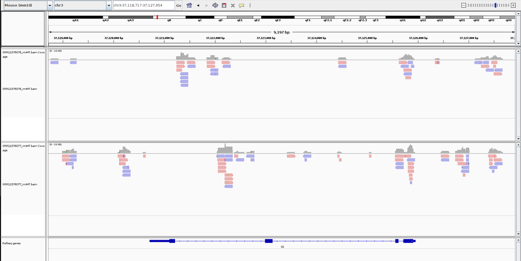

**IL21**

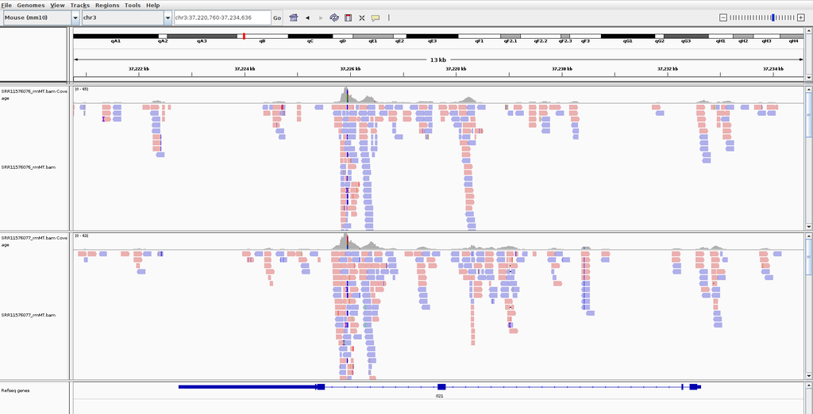

## Estimate the lenght of the fragments

Ended not using them

```bash
macs2 predictd -i /mnt/storage/r0639760/jupyternotebooks/Assignment2/Mapping/bam/SRR11576076_rmMT.bam
```

```
INFO  @ Wed, 16 Dec 2020 11:07:30: # read alignment files...
INFO  @ Wed, 16 Dec 2020 11:07:30: # read treatment tags...
INFO  @ Wed, 16 Dec 2020 11:07:30: Detected format is: BAM
INFO  @ Wed, 16 Dec 2020 11:07:30: * Input file is gzipped.
INFO  @ Wed, 16 Dec 2020 11:07:32:  1000000
INFO  @ Wed, 16 Dec 2020 11:07:34:  2000000
INFO  @ Wed, 16 Dec 2020 11:07:37:  3000000
INFO  @ Wed, 16 Dec 2020 11:07:39:  4000000
INFO  @ Wed, 16 Dec 2020 11:07:42:  5000000
INFO  @ Wed, 16 Dec 2020 11:07:44:  6000000
INFO  @ Wed, 16 Dec 2020 11:07:47:  7000000
INFO  @ Wed, 16 Dec 2020 11:07:49:  8000000
INFO  @ Wed, 16 Dec 2020 11:07:52:  9000000
INFO  @ Wed, 16 Dec 2020 11:07:55:  10000000
INFO  @ Wed, 16 Dec 2020 11:07:57:  11000000
INFO  @ Wed, 16 Dec 2020 11:08:00:  12000000
INFO  @ Wed, 16 Dec 2020 11:08:02:  13000000
INFO  @ Wed, 16 Dec 2020 11:08:05:  14000000
INFO  @ Wed, 16 Dec 2020 11:08:07:  15000000
INFO  @ Wed, 16 Dec 2020 11:08:10:  16000000
INFO  @ Wed, 16 Dec 2020 11:08:12:  17000000
INFO  @ Wed, 16 Dec 2020 11:08:15:  18000000
INFO  @ Wed, 16 Dec 2020 11:08:17:  19000000
INFO  @ Wed, 16 Dec 2020 11:08:20:  20000000
INFO  @ Wed, 16 Dec 2020 11:08:22:  21000000
INFO  @ Wed, 16 Dec 2020 11:08:25:  22000000
INFO  @ Wed, 16 Dec 2020 11:08:27:  23000000
INFO  @ Wed, 16 Dec 2020 11:08:30:  24000000
INFO  @ Wed, 16 Dec 2020 11:08:33:  25000000
INFO  @ Wed, 16 Dec 2020 11:08:35:  26000000
INFO  @ Wed, 16 Dec 2020 11:08:38:  27000000
INFO  @ Wed, 16 Dec 2020 11:08:40:  28000000
INFO  @ Wed, 16 Dec 2020 11:08:43:  29000000
INFO  @ Wed, 16 Dec 2020 11:08:45:  30000000
INFO  @ Wed, 16 Dec 2020 11:08:48: tag size is determined as 145 bps
INFO  @ Wed, 16 Dec 2020 11:08:48: # tag size = 145
INFO  @ Wed, 16 Dec 2020 11:08:48: # total tags in alignment file: 20278648
INFO  @ Wed, 16 Dec 2020 11:08:48: # Build Peak Model...
INFO  @ Wed, 16 Dec 2020 11:08:48: #2 looking for paired plus/minus strand peaks...
INFO  @ Wed, 16 Dec 2020 11:08:51: #2 number of paired peaks: 53192
INFO  @ Wed, 16 Dec 2020 11:08:51: start model_add_line...
INFO  @ Wed, 16 Dec 2020 11:08:52: start X-correlation...
INFO  @ Wed, 16 Dec 2020 11:08:52: end of X-cor
INFO  @ Wed, 16 Dec 2020 11:08:52: # finished!
INFO  @ Wed, 16 Dec 2020 11:08:52: # predicted fragment length is 84 bps
INFO  @ Wed, 16 Dec 2020 11:08:52: # alternative fragment length(s) may be 84 bps
INFO  @ Wed, 16 Dec 2020 11:08:52: # Generate R script for model : predictd
```

```bash
macs2 predictd -i /mnt/storage/r0639760/jupyternotebooks/Assignment2/Mapping/bam/SRR11576077_rmMT.bam
```

```
INFO  @ Wed, 16 Dec 2020 11:08:53: # read alignment files...
INFO  @ Wed, 16 Dec 2020 11:08:53: # read treatment tags...
INFO  @ Wed, 16 Dec 2020 11:08:53: Detected format is: BAM
INFO  @ Wed, 16 Dec 2020 11:08:53: * Input file is gzipped.
INFO  @ Wed, 16 Dec 2020 11:08:55:  1000000
INFO  @ Wed, 16 Dec 2020 11:08:57:  2000000
INFO  @ Wed, 16 Dec 2020 11:09:00:  3000000
INFO  @ Wed, 16 Dec 2020 11:09:02:  4000000
INFO  @ Wed, 16 Dec 2020 11:09:05:  5000000
INFO  @ Wed, 16 Dec 2020 11:09:07:  6000000
INFO  @ Wed, 16 Dec 2020 11:09:10:  7000000
INFO  @ Wed, 16 Dec 2020 11:09:12:  8000000
INFO  @ Wed, 16 Dec 2020 11:09:15:  9000000
INFO  @ Wed, 16 Dec 2020 11:09:17:  10000000
INFO  @ Wed, 16 Dec 2020 11:09:20:  11000000
INFO  @ Wed, 16 Dec 2020 11:09:22:  12000000
INFO  @ Wed, 16 Dec 2020 11:09:25:  13000000
INFO  @ Wed, 16 Dec 2020 11:09:27:  14000000
INFO  @ Wed, 16 Dec 2020 11:09:30:  15000000
INFO  @ Wed, 16 Dec 2020 11:09:32:  16000000
INFO  @ Wed, 16 Dec 2020 11:09:35:  17000000
INFO  @ Wed, 16 Dec 2020 11:09:37:  18000000
INFO  @ Wed, 16 Dec 2020 11:09:40:  19000000
INFO  @ Wed, 16 Dec 2020 11:09:42:  20000000
INFO  @ Wed, 16 Dec 2020 11:09:45:  21000000
INFO  @ Wed, 16 Dec 2020 11:09:47:  22000000
INFO  @ Wed, 16 Dec 2020 11:09:50:  23000000
INFO  @ Wed, 16 Dec 2020 11:09:52:  24000000
INFO  @ Wed, 16 Dec 2020 11:09:55:  25000000
INFO  @ Wed, 16 Dec 2020 11:09:57:  26000000
INFO  @ Wed, 16 Dec 2020 11:10:00:  27000000
INFO  @ Wed, 16 Dec 2020 11:10:02:  28000000
INFO  @ Wed, 16 Dec 2020 11:10:05:  29000000
INFO  @ Wed, 16 Dec 2020 11:10:07:  30000000
INFO  @ Wed, 16 Dec 2020 11:10:10:  31000000
INFO  @ Wed, 16 Dec 2020 11:10:12:  32000000
INFO  @ Wed, 16 Dec 2020 11:10:15:  33000000
INFO  @ Wed, 16 Dec 2020 11:10:17:  34000000
INFO  @ Wed, 16 Dec 2020 11:10:20:  35000000
INFO  @ Wed, 16 Dec 2020 11:10:22:  36000000
INFO  @ Wed, 16 Dec 2020 11:10:23: tag size is determined as 135 bps
INFO  @ Wed, 16 Dec 2020 11:10:23: # tag size = 135
INFO  @ Wed, 16 Dec 2020 11:10:23: # total tags in alignment file: 24413136
INFO  @ Wed, 16 Dec 2020 11:10:23: # Build Peak Model...
INFO  @ Wed, 16 Dec 2020 11:10:23: #2 looking for paired plus/minus strand peaks...
INFO  @ Wed, 16 Dec 2020 11:10:27: #2 number of paired peaks: 57458
INFO  @ Wed, 16 Dec 2020 11:10:27: start model_add_line...
INFO  @ Wed, 16 Dec 2020 11:10:28: start X-correlation...
INFO  @ Wed, 16 Dec 2020 11:10:28: end of X-cor
INFO  @ Wed, 16 Dec 2020 11:10:28: # finished!
INFO  @ Wed, 16 Dec 2020 11:10:28: # predicted fragment length is 80 bps
INFO  @ Wed, 16 Dec 2020 11:10:28: # alternative fragment length(s) may be 80 bps
INFO  @ Wed, 16 Dec 2020 11:10:28: # Generate R script for model : predictd
```

## Creating the pile up file

For ATAC seq usually no control is needed, so we also do not run this here.

```bash
macs2 callpeak -B -t /mnt/storage/r0639760/jupyternotebooks/Assignment2/Mapping/bam/SRR11576076_rmMT.bam -n cre_neg --format BAMPE --keep-dup all
```

```
INFO  @ Wed, 16 Dec 2020 13:15:13:
# Command line: callpeak -B -t /mnt/storage/r0639760/jupyternotebooks/Assignment2/Mapping/bam/SRR11576076_rmMT.bam -n cre_neg --format BAMPE --keep-dup all
# ARGUMENTS LIST:
# name = cre_neg
# format = BAMPE
# ChIP-seq file = ['/mnt/storage/r0639760/jupyternotebooks/Assignment2/Mapping/bam/SRR11576076_rmMT.bam']
# control file = None
# effective genome size = 2.70e+09
# band width = 300
# model fold = [5, 50]
# qvalue cutoff = 5.00e-02
# The maximum gap between significant sites is assigned as the read length/tag size.
# The minimum length of peaks is assigned as the predicted fragment length "d".
# Larger dataset will be scaled towards smaller dataset.
# Range for calculating regional lambda is: 10000 bps
# Broad region calling is off
# Paired-End mode is on

INFO  @ Wed, 16 Dec 2020 13:15:13: #1 read fragment files...
INFO  @ Wed, 16 Dec 2020 13:15:13: #1 read treatment fragments...
INFO  @ Wed, 16 Dec 2020 13:15:17:  1000000
INFO  @ Wed, 16 Dec 2020 13:15:21:  2000000
INFO  @ Wed, 16 Dec 2020 13:15:25:  3000000
INFO  @ Wed, 16 Dec 2020 13:15:30:  4000000
INFO  @ Wed, 16 Dec 2020 13:15:34:  5000000
INFO  @ Wed, 16 Dec 2020 13:15:39:  6000000
INFO  @ Wed, 16 Dec 2020 13:15:44:  7000000
INFO  @ Wed, 16 Dec 2020 13:15:48:  8000000
INFO  @ Wed, 16 Dec 2020 13:15:52:  9000000
INFO  @ Wed, 16 Dec 2020 13:15:57:  10000000
INFO  @ Wed, 16 Dec 2020 13:16:01:  11000000
INFO  @ Wed, 16 Dec 2020 13:16:06:  12000000
INFO  @ Wed, 16 Dec 2020 13:16:10:  13000000
INFO  @ Wed, 16 Dec 2020 13:16:15:  14000000
INFO  @ Wed, 16 Dec 2020 13:16:19:  15000000
INFO  @ Wed, 16 Dec 2020 13:16:23:  16000000
INFO  @ Wed, 16 Dec 2020 13:16:28:  17000000
INFO  @ Wed, 16 Dec 2020 13:16:33:  18000000
INFO  @ Wed, 16 Dec 2020 13:16:37:  19000000
INFO  @ Wed, 16 Dec 2020 13:16:42:  20000000
INFO  @ Wed, 16 Dec 2020 13:16:56: #1 mean fragment size is determined as 140.1 bp from treatment
INFO  @ Wed, 16 Dec 2020 13:16:56: #1 fragment size = 140.1
INFO  @ Wed, 16 Dec 2020 13:16:56: #1  total fragments in treatment: 20278648
INFO  @ Wed, 16 Dec 2020 13:16:56: #1 finished!
INFO  @ Wed, 16 Dec 2020 13:16:56: #2 Build Peak Model...
INFO  @ Wed, 16 Dec 2020 13:16:56: #2 Skipped...
INFO  @ Wed, 16 Dec 2020 13:16:56: #3 Call peaks...
INFO  @ Wed, 16 Dec 2020 13:16:56: #3 Pre-compute pvalue-qvalue table...
INFO  @ Wed, 16 Dec 2020 13:17:36: #3 In the peak calling step, the following will be performed simultaneously:
INFO  @ Wed, 16 Dec 2020 13:17:36: #3   Write bedGraph files for treatment pileup (after scaling if necessary)... cre_neg_treat_pileup.bdg
INFO  @ Wed, 16 Dec 2020 13:17:36: #3   Write bedGraph files for control lambda (after scaling if necessary)... cre_neg_control_lambda.bdg
INFO  @ Wed, 16 Dec 2020 13:17:36: #3   Pileup will be based on sequencing depth in treatment.
INFO  @ Wed, 16 Dec 2020 13:17:36: #3 Call peaks for each chromosome...
INFO  @ Wed, 16 Dec 2020 13:47:24: #4 Write output xls file... cre_neg_peaks.xls
INFO  @ Wed, 16 Dec 2020 13:47:24: #4 Write peak in narrowPeak format file... cre_neg_peaks.narrowPeak
INFO  @ Wed, 16 Dec 2020 13:47:25: #4 Write summits bed file... cre_neg_summits.bed
INFO  @ Wed, 16 Dec 2020 13:47:25: Done!
```

```bash
macs2 callpeak -B -t /mnt/storage/r0639760/jupyternotebooks/Assignment2/Mapping/bam/SRR11576077_rmMT.bam -n cre_pos --format BAMPE --keep-dup all
```

```
INFO  @ Wed, 16 Dec 2020 13:47:25:
# Command line: callpeak -B -t /mnt/storage/r0639760/jupyternotebooks/Assignment2/Mapping/bam/SRR11576077_rmMT.bam -n cre_pos --format BAMPE --keep-dup all
# ARGUMENTS LIST:
# name = cre_pos
# format = BAMPE
# ChIP-seq file = ['/mnt/storage/r0639760/jupyternotebooks/Assignment2/Mapping/bam/SRR11576077_rmMT.bam']
# control file = None
# effective genome size = 2.70e+09
# band width = 300
# model fold = [5, 50]
# qvalue cutoff = 5.00e-02
# The maximum gap between significant sites is assigned as the read length/tag size.
# The minimum length of peaks is assigned as the predicted fragment length "d".
# Larger dataset will be scaled towards smaller dataset.
# Range for calculating regional lambda is: 10000 bps
# Broad region calling is off
# Paired-End mode is on

INFO  @ Wed, 16 Dec 2020 13:47:25: #1 read fragment files...
INFO  @ Wed, 16 Dec 2020 13:47:25: #1 read treatment fragments...
INFO  @ Wed, 16 Dec 2020 13:47:29:  1000000
INFO  @ Wed, 16 Dec 2020 13:47:32:  2000000
INFO  @ Wed, 16 Dec 2020 13:47:37:  3000000
INFO  @ Wed, 16 Dec 2020 13:47:41:  4000000
INFO  @ Wed, 16 Dec 2020 13:47:46:  5000000
INFO  @ Wed, 16 Dec 2020 13:47:50:  6000000
INFO  @ Wed, 16 Dec 2020 13:47:54:  7000000
INFO  @ Wed, 16 Dec 2020 13:47:59:  8000000
INFO  @ Wed, 16 Dec 2020 13:48:03:  9000000
INFO  @ Wed, 16 Dec 2020 13:48:07:  10000000
INFO  @ Wed, 16 Dec 2020 13:48:11:  11000000
INFO  @ Wed, 16 Dec 2020 13:48:16:  12000000
INFO  @ Wed, 16 Dec 2020 13:48:20:  13000000
INFO  @ Wed, 16 Dec 2020 13:48:24:  14000000
INFO  @ Wed, 16 Dec 2020 13:48:28:  15000000
INFO  @ Wed, 16 Dec 2020 13:48:32:  16000000
INFO  @ Wed, 16 Dec 2020 13:48:37:  17000000
INFO  @ Wed, 16 Dec 2020 13:48:41:  18000000
INFO  @ Wed, 16 Dec 2020 13:48:45:  19000000
INFO  @ Wed, 16 Dec 2020 13:48:49:  20000000
INFO  @ Wed, 16 Dec 2020 13:48:54:  21000000
INFO  @ Wed, 16 Dec 2020 13:48:58:  22000000
INFO  @ Wed, 16 Dec 2020 13:49:02:  23000000
INFO  @ Wed, 16 Dec 2020 13:49:06:  24000000
INFO  @ Wed, 16 Dec 2020 13:49:24: #1 mean fragment size is determined as 128.6 bp from treatment
INFO  @ Wed, 16 Dec 2020 13:49:24: #1 fragment size = 128.6
INFO  @ Wed, 16 Dec 2020 13:49:24: #1  total fragments in treatment: 24413136
INFO  @ Wed, 16 Dec 2020 13:49:24: #1 finished!
INFO  @ Wed, 16 Dec 2020 13:49:24: #2 Build Peak Model...
INFO  @ Wed, 16 Dec 2020 13:49:24: #2 Skipped...
INFO  @ Wed, 16 Dec 2020 13:49:24: #3 Call peaks...
INFO  @ Wed, 16 Dec 2020 13:49:24: #3 Pre-compute pvalue-qvalue table...
INFO  @ Wed, 16 Dec 2020 13:50:07: #3 In the peak calling step, the following will be performed simultaneously:
INFO  @ Wed, 16 Dec 2020 13:50:07: #3   Write bedGraph files for treatment pileup (after scaling if necessary)... cre_pos_treat_pileup.bdg
INFO  @ Wed, 16 Dec 2020 13:50:07: #3   Write bedGraph files for control lambda (after scaling if necessary)... cre_pos_control_lambda.bdg
INFO  @ Wed, 16 Dec 2020 13:50:07: #3   Pileup will be based on sequencing depth in treatment.
INFO  @ Wed, 16 Dec 2020 13:50:07: #3 Call peaks for each chromosome...
INFO  @ Wed, 16 Dec 2020 14:20:58: #4 Write output xls file... cre_pos_peaks.xls
INFO  @ Wed, 16 Dec 2020 14:20:59: #4 Write peak in narrowPeak format file... cre_pos_peaks.narrowPeak
INFO  @ Wed, 16 Dec 2020 14:20:59: #4 Write summits bed file... cre_pos_summits.bed
INFO  @ Wed, 16 Dec 2020 14:20:59: Done!
```

## Count number of peaks

```bash
egrep 'chr[0-9]+|chrX|chrY' cre_neg_peaks.xls | wc -l
```

```
180069
```

```bash
egrep 'chr[0-9]+|chrX|chrY' cre_pos_peaks.xls  | wc -l
```

```
120058
```

## Check the narrow peak files in IGV

**IL2** For IL2 there were no peaks called, this is most likely because the q-value for these peaks is below the threshold that is default set to 0.05.

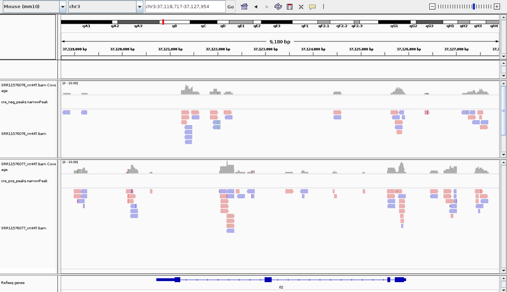

**IL21** For IL21 we see that peaks were called in both the Thopk knock-out samples (*77) and the wt (*76).

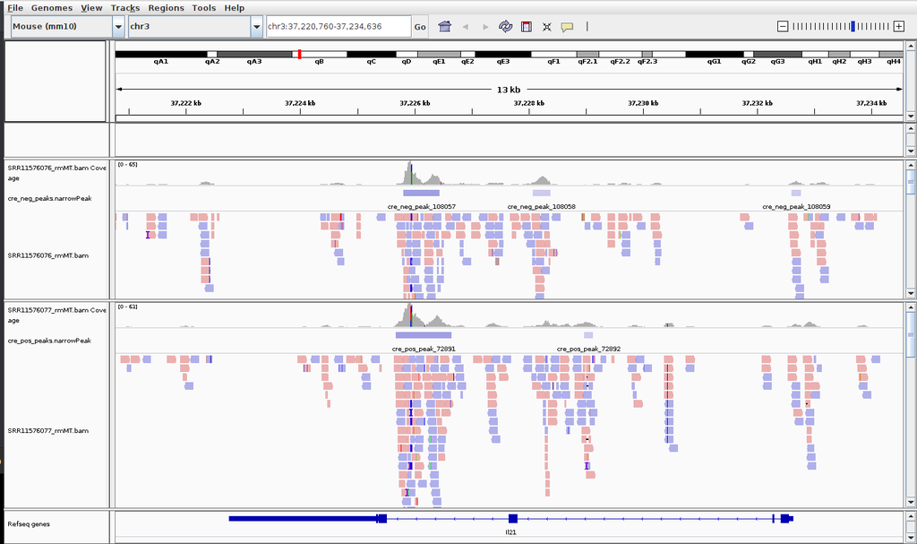

```bash
macs2 bdgdiff \
    --t1 cre_pos_treat_pileup.bdg  \
    --t2 cre_neg_treat_pileup.bdg  \
    --c1 cre_pos_control_lambda.bdg \
    --c2 cre_neg_control_lambda.bdg \
    --d1 180069 --d2 120058 -g 60 -l 120 \
    --o-prefix diff_pos_vs_neg
```

```
INFO  @ Wed, 16 Dec 2020 16:47:25: Read and build treatment 1 bedGraph...
INFO  @ Wed, 16 Dec 2020 16:47:34: Read and build control 1 bedGraph...
INFO  @ Wed, 16 Dec 2020 16:47:41: Read and build treatment 2 bedGraph...
INFO  @ Wed, 16 Dec 2020 16:47:49: Read and build control 2 bedGraph...
INFO  @ Wed, 16 Dec 2020 16:48:41: Write peaks...
INFO  @ Wed, 16 Dec 2020 16:48:41: Done
```

```bash
macs2 bdgdiff -h
```

```
usage: macs2 bdgdiff [-h] --t1 T1BDG --t2 T2BDG --c1 C1BDG --c2 C2BDG
                     [-C CUTOFF] [-l MINLEN] [-g MAXGAP] [--d1 DEPTH1]
                     [--d2 DEPTH2] [--outdir OUTDIR]
                     (--o-prefix OPREFIX | -o OFILE OFILE OFILE)

optional arguments:
  -h, --help            show this help message and exit
  --t1 T1BDG            MACS pileup bedGraph for condition 1. Incompatible
                        with callpeak --SPMR output. REQUIRED
  --t2 T2BDG            MACS pileup bedGraph for condition 2. Incompatible
                        with callpeak --SPMR output. REQUIRED
  --c1 C1BDG            MACS control lambda bedGraph for condition 1.
                        Incompatible with callpeak --SPMR output. REQUIRED
  --c2 C2BDG            MACS control lambda bedGraph for condition 2.
                        Incompatible with callpeak --SPMR output. REQUIRED
  -C CUTOFF, --cutoff CUTOFF
                        logLR cutoff. DEFAULT: 3 (likelihood ratio=1000)
  -l MINLEN, --min-len MINLEN
                        Minimum length of differential region. Try bigger
                        value to remove small regions. DEFAULT: 200
  -g MAXGAP, --max-gap MAXGAP
                        Maximum gap to merge nearby differential regions.
                        Consider a wider gap for broad marks. Maximum gap
                        should be smaller than minimum length (-g). DEFAULT:
                        100
  --d1 DEPTH1, --depth1 DEPTH1
                        Sequencing depth (# of non-redundant reads in million)
                        for condition 1. It will be used together with --d2.
                        See description for --d2 below for how to assign them.
                        Default: 1
  --d2 DEPTH2, --depth2 DEPTH2
                        Sequencing depth (# of non-redundant reads in million)
                        for condition 2. It will be used together with --d1.
                        DEPTH1 and DEPTH2 will be used to calculate scaling
                        factor for each sample, to down-scale larger sample to
                        the level of smaller one. For example, while comparing
                        10 million condition 1 and 20 million condition 2, use
                        --d1 10 --d2 20, then pileup value in bedGraph for
                        condition 2 will be divided by 2. Default: 1
  --outdir OUTDIR       If specified all output files will be written to that
                        directory. Default: the current working directory
  --o-prefix OPREFIX    Output file prefix. Actual files will be named as
                        PREFIX_cond1.bed, PREFIX_cond2.bed and
                        PREFIX_common.bed. Mutually exclusive with -o/--ofile.
  -o OFILE OFILE OFILE, --ofile OFILE OFILE OFILE
                        Output filenames. Must give three arguments in order:
                        1. file for unique regions in condition 1; 2. file for
                        unique regions in condition 2; 3. file for common
                        regions in both conditions. Note: mutually exclusive
                        with --o-prefix.
```

```bash
cat diff_pos_vs_neg_c3.0_cond1.bed | sort -k 5,5gr | wc -l
```

```
6617
```

```bash
cat diff_pos_vs_neg_c3.0_cond1.bed | sort -k 5,5gr | head
```

```
chr6	124884915	124886744	diff_pos_vs_neg_cond1_5368	286.72440
chr6	124883186	124883415	diff_pos_vs_neg_cond1_5367	199.08167
chr6	124879671	124880419	diff_pos_vs_neg_cond1_5366	128.64331
chr3	89367455	89367757	diff_pos_vs_neg_cond1_4159	43.77084
chr2	70825839	70826010	diff_pos_vs_neg_cond1_3617	40.82513
chr6	124887834	124888356	diff_pos_vs_neg_cond1_5369	39.50915
chr1	182554178	182554426	diff_pos_vs_neg_cond1_373	35.15197
chr6	86525986	86526209	diff_pos_vs_neg_cond1_5241	33.86000
chr8	125293486	125293659	diff_pos_vs_neg_cond1_6135	31.78811
chr12	86843171	86843497	diff_pos_vs_neg_cond1_1386	30.88583
sort: write failed: 'standard output': Broken pipe
sort: write error
```

```bash
cat diff_pos_vs_neg_c3.0_cond2.bed | sort -k 5,5gr | wc -l
```

```
27546
```

We see here how important Thpok is for the expression of many genes, we do not know which ones but we have 4 times as many regions that are accesible in more copies than in the KO.

```bash
cat diff_pos_vs_neg_c3.0_cond2.bed | sort -k 5,5gr | head
```

```
chr2	98666243	98667321	diff_pos_vs_neg_cond2_15296	6419.59570
chr1	24612803	24616140	diff_pos_vs_neg_cond2_218	1407.14246
chr12	3109866	3110111	diff_pos_vs_neg_cond2_4742	1058.96643
chr1	24611622	24612680	diff_pos_vs_neg_cond2_217	961.45557
chr9	35305220	35305590	diff_pos_vs_neg_cond2_25587	773.45032
chr2	98662233	98662821	diff_pos_vs_neg_cond2_15294	679.61792
chr14	19415718	19419409	diff_pos_vs_neg_cond2_7909	640.65540
chr6	103649045	103649296	diff_pos_vs_neg_cond2_22079	609.01288
chr2	98665008	98665210	diff_pos_vs_neg_cond2_15295	336.68661
chr12	97061431	97061667	diff_pos_vs_neg_cond2_5743	98.95628
sort: write failed: 'standard output': Broken pipe
sort: write error
```

```bash
cat diff_pos_vs_neg_c3.0_common.bed | sort -k 5,5gr | wc -l
```

```
41488
```

```bash
cat diff_pos_vs_neg_c3.0_common.bed | sort -k 5,5gr | head
```

```
chr2	158207768	158207947	diff_pos_vs_neg_common_23988	2.87978
chr1	72307083	72307222	diff_pos_vs_neg_common_848	2.87920
chr10	37139937	37140102	diff_pos_vs_neg_common_3384	2.80487
chr1	133181279	133181403	diff_pos_vs_neg_common_1563	2.80404
chr15	25621956	25622102	diff_pos_vs_neg_common_13613	2.79377
chr7	92874463	92874589	diff_pos_vs_neg_common_35375	2.74282
chr13	119600692	119600820	diff_pos_vs_neg_common_11617	2.74115
chr17	28432355	28432501	diff_pos_vs_neg_common_17470	2.73161
chr9	119341642	119341775	diff_pos_vs_neg_common_40238	2.71378
chr7	45567860	45567991	diff_pos_vs_neg_common_34659	2.70905
sort: write failed: 'standard output': Broken pipe
sort: write error
```

## i-cis target

(later i learned that mm10 and mm9 can easily be tranformed in one another, but that I did not know in this moment) https://gbiomed.kuleuven.be/apps/lcb/i-cisTarget/reports/dbcc3263e275941a7ab8df29f168870f24bc94d0/report.html

```bash
wget https://gbiomed.kuleuven.be/apps/lcb/i-cisTarget/reports/dbcc3263e275941a7ab8df29f168870f24bc94d0/archive.zip
```

```
--2020-12-16 17:38:37--  https://gbiomed.kuleuven.be/apps/lcb/i-cisTarget/reports/dbcc3263e275941a7ab8df29f168870f24bc94d0/archive.zip
Resolving gbiomed.kuleuven.be (gbiomed.kuleuven.be)... 134.58.64.23, 2a02:2c40:0:80::80:23
Connecting to gbiomed.kuleuven.be (gbiomed.kuleuven.be)|134.58.64.23|:443... connected.
HTTP request sent, awaiting response... 200 OK
Length: 16656704 (16M) [application/zip]
Saving to: ‘archive.zip’

archive.zip         100%[===================>]  15.88M  83.1MB/s    in 0.2s

2020-12-16 17:38:37 (83.1 MB/s) - ‘archive.zip’ saved [16656704/16656704]
```

i-CisTarget does not have the mm10 available but only mm9 for motif finding, so we need to look out for something else such as Homer.

## Homer als alternative to i-cis targer supporting mm10

### Installation

```bash
cd Homer
```

```bash
wget http://homer.ucsd.edu/homer/configureHomer.pl
```

```
--2020-12-16 18:33:13--  http://homer.ucsd.edu/homer/configureHomer.pl
Resolving homer.ucsd.edu (homer.ucsd.edu)... 169.228.63.226
Connecting to homer.ucsd.edu (homer.ucsd.edu)|169.228.63.226|:80... connected.
HTTP request sent, awaiting response... 200 OK
Length: 27477 (27K) [application/x-perl]
Saving to: ‘configureHomer.pl’

configureHomer.pl   100%[===================>]  26.83K   172KB/s    in 0.2s

2020-12-16 18:33:13 (172 KB/s) - ‘configureHomer.pl’ saved [27477/27477]
```

```bash
perl configureHomer.pl -install homer
```

[output not shown]

[output cut: 109 more lines]

[output not shown]

```bash
PATH=$PATH:/mnt/storage/r0639760/jupyternotebooks/Assignment2/Homer/.//bin/
perl configureHomer.pl -install mm10
```

[output not shown]

[output cut: 52 more lines]

```
	Installing: mm10
		Downloading...
--2020-12-16 18:34:46--  http://homer.ucsd.edu/homer/data/genomes/mm10.v6.4.zip
Resolving homer.ucsd.edu (homer.ucsd.edu)... 169.228.63.226
Connecting to homer.ucsd.edu (homer.ucsd.edu)|169.228.63.226|:80... connected.
HTTP request sent, awaiting response... 200 OK
Length: 1363484460 (1.3G) [application/zip]
Saving to: ‘homer.package.zip’

homer.package.zip   100%[===================>]   1.27G  18.7MB/s    in 73s

2020-12-16 18:35:59 (17.8 MB/s) - ‘homer.package.zip’ saved [1363484460/1363484460]

		Unzipping...
		Finished Installing mm10
```

### Peak annotation

```bash
mkdir -p results
bin/annotatePeaks.pl ../diff_pos_vs_neg_c3.0_cond1.bed mm10 > results/annotations_cre_pos
```

```
	Peak file = ../diff_pos_vs_neg_c3.0_cond1.bed
	Genome = mm10
	Organism = mouse
	Peak/BED file conversion summary:
		BED/Header formatted lines: 6616
		peakfile formatted lines: 0
		Duplicated Peak IDs: 0

	Peak File Statistics:
		Total Peaks: 6616
		Redundant Peak IDs: 0
		Peaks lacking information: 0 (need at least 5 columns per peak)
		Peaks with misformatted coordinates: 0 (should be integer)
		Peaks with misformatted strand: 0 (should be either +/- or 0/1)

	Peak file looks good!

	Reading Positions...
	-----------------------
	Finding Closest TSS...
	Annotating:....................
		Annotation	Number of peaks	Total size (bp)	Log2 Ratio (obs/exp)	LogP enrichment (+values depleted)
		3UTR	64.0	20746162	0.295	-2.792
		miRNA	0.0	31126	-0.109	0.078
		ncRNA	24.0	3439613	1.472	-11.254
		TTS	119.0	27176332	0.800	-18.010
		pseudo	0.0	540203	-1.238	1.359
		Exon	224.0	34540955	1.367	-79.631
		Intron	2687.0	947608369	0.173	-32.631
		Intergenic	2655.0	1564039797	-0.567	504.275
		Promoter	744.0	30063639	3.299	-1072.162
		5UTR	99.0	2354993	4.063	-189.543
		snoRNA	0.0	19	-0.000	0.000
		rRNA	0.0	5631	-0.020	0.014
	NOTE: If this part takes more than 2 minutes, there is a good chance
		your machine ran out of memory: consider hitting ctrl+C and rerunning
		the command with "-noann"
	To capture annotation stats in a file, use "-annStats <filename>" next time
	Annotating:....................
		Annotation	Number of peaks	Total size (bp)	Log2 Ratio (obs/exp)	LogP enrichment (+values depleted)
```

[output cut: 23 more lines]

```
		scRNA	0.0	577291	-1.294	1.451
		CpG-Island	190.0	3107258	4.604	-430.207
		Low_complexity	38.0	18489411	-0.291	2.138
		LTR	502.0	292929648	-0.553	49.591
		Simple_repeat	90.0	55283218	-0.627	12.224
		snRNA	0.0	236859	-0.674	0.595
		Unknown	1.0	1234764	-1.634	1.692
		SINE?	0.0	29758	-0.104	0.075
		Satellite	14.0	3685416	0.596	-2.432
		rRNA	0.0	165655	-0.502	0.416
	Counting Tags in Peaks from each directory...
	Organism: mouse
	Loading Gene Informaiton...
	Outputing Annotation File...
	Done annotating peaks file
```

```bash
mkdir -p results
bin/annotatePeaks.pl ../diff_pos_vs_neg_c3.0_cond2.bed mm10 > results/annotations_cre_neg
```

```
	Peak file = ../diff_pos_vs_neg_c3.0_cond2.bed
	Genome = mm10
	Organism = mouse
	Peak/BED file conversion summary:
		BED/Header formatted lines: 27545
		peakfile formatted lines: 0
		Duplicated Peak IDs: 0

	Peak File Statistics:
		Total Peaks: 27545
		Redundant Peak IDs: 0
		Peaks lacking information: 0 (need at least 5 columns per peak)
		Peaks with misformatted coordinates: 0 (should be integer)
		Peaks with misformatted strand: 0 (should be either +/- or 0/1)

	Peak file looks good!

	Reading Positions...
	-----------------------
	Finding Closest TSS...
	Annotating:.....................
		Annotation	Number of peaks	Total size (bp)	Log2 Ratio (obs/exp)	LogP enrichment (+values depleted)
		3UTR	179.0	20758984	-0.231	4.182
		miRNA	1.0	31126	1.666	-1.308
		ncRNA	46.0	3444819	0.400	-3.212
		TTS	248.0	27310824	-0.157	3.127
		pseudo	8.0	546038	0.534	-1.641
		Exon	520.0	34637734	0.569	-39.047
		Intron	9495.0	949817418	-0.018	2.697
		Intergenic	14945.0	1652260349	-0.162	240.768
		Promoter	1884.0	30199116	2.624	-1899.147
		5UTR	215.0	2375187	3.161	-284.228
		snoRNA	0.0	19	-0.000	0.000
		rRNA	4.0	5631	6.133	-14.683
	NOTE: If this part takes more than 2 minutes, there is a good chance
		your machine ran out of memory: consider hitting ctrl+C and rerunning
		the command with "-noann"
	To capture annotation stats in a file, use "-annStats <filename>" next time
	Annotating:.....................
		Annotation	Number of peaks	Total size (bp)	Log2 Ratio (obs/exp)	LogP enrichment (+values depleted)
```

[output cut: 23 more lines]

```
		scRNA	2.0	602434	-1.608	2.850
		CpG-Island	384.0	3120067	3.605	-613.079
		Low_complexity	85.0	19380269	-1.206	42.834
		LTR	2909.0	312893904	-0.122	14.526
		Simple_repeat	412.0	57509780	-0.498	30.882
		snRNA	1.0	237028	-1.262	1.175
		Unknown	7.0	2405032	-1.797	10.201
		SINE?	0.0	29758	-0.380	0.301
		Satellite	45.0	4519924	-0.023	0.701
		rRNA	10.0	166488	2.570	-11.412
	Counting Tags in Peaks from each directory...
	Organism: mouse
	Loading Gene Informaiton...
	Outputing Annotation File...
	Done annotating peaks file
```

## Motif enrichment analysis with homer

```bash
bin/findMotifsGenome.pl ../diff_pos_vs_neg_c3.0_cond1.bed mm10  results/motifs_cre_pos -size 200
```

```
	Position file = ../diff_pos_vs_neg_c3.0_cond1.bed
	Genome = mm10
	Output Directory = results/motifs_cre_pos
	Fragment size set to 200
	Found mset for "mouse", will check against vertebrates motifs
	Peak/BED file conversion summary:
		BED/Header formatted lines: 6616
		peakfile formatted lines: 0

	Peak File Statistics:
		Total Peaks: 6616
		Redundant Peak IDs: 0
		Peaks lacking information: 0 (need at least 5 columns per peak)
		Peaks with misformatted coordinates: 0 (should be integer)
		Peaks with misformatted strand: 0 (should be either +/- or 0/1)

	Peak file looks good!

	Background files for 200 bp fragments found.
	Custom genome sequence directory: /mnt/storage/r0639760/jupyternotebooks/Assignment2/Homer/.//data/genomes/mm10//

	Extracting sequences from directory: /mnt/storage/r0639760/jupyternotebooks/Assignment2/Homer/.//data/genomes/mm10//
	Extracting 404 sequences from chr1
	Extracting 543 sequences from chr2
	Extracting 365 sequences from chr3
	Extracting 389 sequences from chr4
	Extracting 352 sequences from chr5
	Extracting 402 sequences from chr6
	Extracting 362 sequences from chr7
	Extracting 317 sequences from chr8
	Extracting 286 sequences from chr9
	Extracting 375 sequences from chr10
	Extracting 426 sequences from chr11
	Extracting 277 sequences from chr12
	Extracting 287 sequences from chr13
	Extracting 308 sequences from chr14
	Extracting 342 sequences from chr15
	Extracting 261 sequences from chr16
	Extracting 332 sequences from chr17
	Extracting 224 sequences from chr18
```

[output cut: 835 more lines]

```
		27 of 38 (1e-6) similar to Ptf1a(var.2)/MA1619.1/Jaspar(0.722)
		28 of 38 (1e-5) similar to PBX1/MA0070.1/Jaspar(0.763)
		29 of 38 (1e-5) similar to CREB3L4/MA1474.1/Jaspar(0.686)
		30 of 38 (1e-5) similar to KLF4/MA0039.4/Jaspar(0.837)
		31 of 38 (1e-4) similar to Smad2(MAD)/ES-SMAD2-ChIP-Seq(GSE29422)/Homer(0.638)
		32 of 38 (1e-4) similar to PB0099.1_Zfp691_1/Jaspar(0.689)
		33 of 38 (1e-3) similar to Tcf12/MA0521.1/Jaspar(0.637)
		34 of 38 (1e-3) similar to Smad4(MAD)/ESC-SMAD4-ChIP-Seq(GSE29422)/Homer(0.664)
		35 of 38 (1e-3) similar to ZNF263/MA0528.2/Jaspar(0.656)
		36 of 38 (1e-3) similar to Zfp57(Zf)/H1-ZFP57.HA-ChIP-Seq(GSE115387)/Homer(0.650)
		37 of 38 (1e-3) similar to TBX6/MA1567.1/Jaspar(0.620)
		38 of 38 (1e-1) similar to EWS:FLI1-fusion(ETS)/SK_N_MC-EWS:FLI1-ChIP-Seq(SRA014231)/Homer(0.608)
	Job finished - if results look good, please send beer to ..

	Cleaning up tmp files...
```

```bash
bin/findMotifsGenome.pl ../diff_pos_vs_neg_c3.0_cond2.bed mm10  results/motifs_cre_neg -size 200
```

```
	Position file = ../diff_pos_vs_neg_c3.0_cond2.bed
	Genome = mm10
	Output Directory = results/motifs_cre_neg
	Fragment size set to 200
	Found mset for "mouse", will check against vertebrates motifs
	Peak/BED file conversion summary:
		BED/Header formatted lines: 27545
		peakfile formatted lines: 0

	Peak File Statistics:
		Total Peaks: 27545
		Redundant Peak IDs: 0
		Peaks lacking information: 0 (need at least 5 columns per peak)
		Peaks with misformatted coordinates: 0 (should be integer)
		Peaks with misformatted strand: 0 (should be either +/- or 0/1)

	Peak file looks good!

	Background files for 200 bp fragments found.
	Custom genome sequence directory: /mnt/storage/r0639760/jupyternotebooks/Assignment2/Homer/.//data/genomes/mm10//

	Extracting sequences from directory: /mnt/storage/r0639760/jupyternotebooks/Assignment2/Homer/.//data/genomes/mm10//
	Extracting 2139 sequences from chr1
	Extracting 2162 sequences from chr2
	Extracting 2055 sequences from chr3
	Extracting 1363 sequences from chr4
	Extracting 1375 sequences from chr5
	Extracting 1784 sequences from chr6
	Extracting 1230 sequences from chr7
	Extracting 1262 sequences from chr8
	Extracting 984 sequences from chr9
	Extracting 1816 sequences from chr10
	Extracting 784 sequences from chr11
	Extracting 1252 sequences from chr12
	Extracting 1682 sequences from chr13
	Extracting 1282 sequences from chr14
	Extracting 1163 sequences from chr15
	Extracting 1393 sequences from chr16
	Extracting 1031 sequences from chr17
	Extracting 1036 sequences from chr18
```

[output cut: 869 more lines]

```
		27 of 38 (1e-26) similar to ZNF354C/MA0130.1/Jaspar(0.760)
		28 of 38 (1e-25) similar to PB0124.1_Gabpa_2/Jaspar(0.684)
		29 of 38 (1e-24) similar to PB0156.1_Plagl1_2/Jaspar(0.788)
		30 of 38 (1e-23) similar to MITF(bHLH)/MastCells-MITF-ChIP-Seq(GSE48085)/Homer(0.639)
		31 of 38 (1e-22) similar to PB0110.1_Bcl6b_2/Jaspar(0.759)
		32 of 38 (1e-19) similar to IRF4(IRF)/GM12878-IRF4-ChIP-Seq(GSE32465)/Homer(0.782)
		33 of 38 (1e-19) similar to ZNF768(Zf)/Rajj-ZNF768-ChIP-Seq(GSE111879)/Homer(0.763)
		34 of 38 (1e-15) similar to NEUROG2/MA0669.1/Jaspar(0.710)
		35 of 38 (1e-11) similar to ZNF317/MA1593.1/Jaspar(0.632)
		36 of 38 (1e-10) similar to CRX(Homeobox)/Retina-Crx-ChIP-Seq(GSE20012)/Homer(0.693)
		37 of 38 (1e-9) similar to PB0106.1_Arid5a_2/Jaspar(0.608)
		38 of 38 (1e-2) similar to CUX1(Homeobox)/K562-CUX1-ChIP-Seq(GSE92882)/Homer(0.685)
	Job finished - if results look good, please send beer to ..

	Cleaning up tmp files...
```

## Enriched motifs in the mice with wt Thpok in CD4+ cells

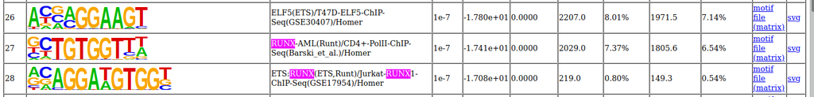

We see that in the wt we have enrichment for the Runx motif as claimed by the authors in CD4+ cells. This makes sense because Thpok binding to the DNA could make the DNA accesible for ATAC sequncing t regions where there are binding sites for Runx as well. This could mean that Thpok is there first and after Runx is recruited.

## Enriched motifs in the mice with knock-out Thpok in CD4+ cells

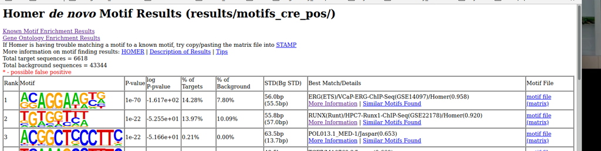

We see that RUNX motif is enriched for the knock-out mice as well but in different cells not the CD4+ cells. Would that be compensation, or is just an artifact?

## Overlap of ATAC seq peaks with CbFB peks called in another chipseq experiment

Code from chromatin notebook

```bash
wc -l cre_pos_peaks.narrowPeak
```

[output not shown]

```bash
wc -l cre_neg_peaks.narrowPeak
```

[output not shown]

```bash
cat cre_pos_peaks.narrowPeak | cut -f 1-3 > cre_pos_peaks.bed
cat cre_neg_peaks.narrowPeak | cut -f 1-3 > cre_neg_peaks.bed
cat cre_pos_peaks.bed | head
```

```
chr1	3049415	3049795
chr1	3098194	3098421
chr1	3150005	3150184
chr1	3193443	3193628
chr1	3213607	3213882
chr1	3251249	3251413
chr1	3300159	3300316
chr1	3309699	3309929
chr1	3310596	3310768
chr1	3438969	3439144
cat: write error: Broken pipe
```

```bash
bamCoverage -b Mapping/bam/SRR11576076_rmMT.bam --normalizeUsing RPGC --effectiveGenomeSize 2652783500 -o SRR11576076_rmMT.bw
```

```
normalization: 1x (effective genome size 2652783500)
bamFilesList: ['Mapping/bam/SRR11576076_rmMT.bam']
binLength: 50
numberOfSamples: None
blackListFileName: None
skipZeroOverZero: False
bed_and_bin: False
genomeChunkSize: None
defaultFragmentLength: read length
numberOfProcessors: 1
verbose: False
region: None
bedFile: None
minMappingQuality: None
ignoreDuplicates: False
chrsToSkip: []
stepSize: 50
center_read: False
samFlag_include: None
samFlag_exclude: None
minFragmentLength: 0
maxFragmentLength: 0
zerosToNans: False
smoothLength: None
save_data: False
out_file_for_raw_data: None
maxPairedFragmentLength: 1000
```

```bash
bamCoverage -b Mapping/bam/SRR11576077_rmMT.bam --normalizeUsing RPGC --effectiveGenomeSize 2652783500 -o SRR11576077_rmMT.bw
```

```
normalization: 1x (effective genome size 2652783500)
bamFilesList: ['Mapping/bam/SRR11576077_rmMT.bam']
binLength: 50
numberOfSamples: None
blackListFileName: None
skipZeroOverZero: False
bed_and_bin: False
genomeChunkSize: None
defaultFragmentLength: read length
numberOfProcessors: 1
verbose: False
region: None
bedFile: None
minMappingQuality: None
ignoreDuplicates: False
chrsToSkip: []
stepSize: 50
center_read: False
samFlag_include: None
samFlag_exclude: None
minFragmentLength: 0
maxFragmentLength: 0
zerosToNans: False
smoothLength: None
save_data: False
out_file_for_raw_data: None
maxPairedFragmentLength: 1000
```

## CbfB overlap

Chipseq peaks for CbFB were found online https://www.ncbi.nlm.nih.gov/geo/query/acc.cgi?acc=GSM832316 this was aligned to mm9 and was translated to mm10 using http://genome.ucsc.edu/cgi-bin/hgLiftOver

```bash
wget ftp://ftp.ncbi.nlm.nih.gov/geo/samples/GSM832nnn/GSM832316/suppl/GSM832316%5FCBFb%5Funinduced%5Fpeaks%2Ebed%2Egz
```

```
--2020-12-18 11:15:32--  ftp://ftp.ncbi.nlm.nih.gov/geo/samples/GSM832nnn/GSM832316/suppl/GSM832316%5FCBFb%5Funinduced%5Fpeaks%2Ebed%2Egz
           => ‘GSM832316_CBFb_uninduced_peaks.bed.gz’
Resolving ftp.ncbi.nlm.nih.gov (ftp.ncbi.nlm.nih.gov)... 130.14.250.10, 2607:f220:41e:250::13, 2607:f220:41e:250::7, ...
Connecting to ftp.ncbi.nlm.nih.gov (ftp.ncbi.nlm.nih.gov)|130.14.250.10|:21... connected.
Logging in as anonymous ... Logged in!
==> SYST ... done.    ==> PWD ... done.
==> TYPE I ... done.  ==> CWD (1) /geo/samples/GSM832nnn/GSM832316/suppl ... done.
==> SIZE GSM832316_CBFb_uninduced_peaks.bed.gz ... 56229
==> PASV ... done.    ==> RETR GSM832316_CBFb_uninduced_peaks.bed.gz ... done.
Length: 56229 (55K) (unauthoritative)

GSM832316_CBFb_unin 100%[===================>]  54.91K   269KB/s    in 0.2s

2020-12-18 11:15:34 (269 KB/s) - ‘GSM832316_CBFb_uninduced_peaks.bed.gz’ saved [56229]
```

```bash
computeMatrix scale-regions \
    -S SRR11576076_rmMT.bw SRR11576077_rmMT.bw \
    -R GSM832316_CBFb_uninduced_peaks_mm10.bed \
    -a 2000 \
    -b 2000 \
    -out peaks_ATAC.tab.gz
```

```
Skipping chr4_GL456216_random:173-2611, due to being absent in the computeMatrix output.
Skipping chr4_GL456216_random:15168-17624, due to being absent in the computeMatrix output.
```

```bash
plotHeatmap \
    -m peaks_ATAC.tab.gz \
    -out peaks-ATAC.png \
    --heatmapHeight 15 \
    --refPointLabel peak.center \
    --regionsLabel peaks \
    --plotTitle 'Peaks ATAC-seq signal'
```

## Overlap CbFB biding sites with coverage of KO versus wt

We do not see large differences in the peaks that are called for KO versus wt sites for CbFB but this might be because we look at genome wide CbFB sites and we only expect an increased accesibility in wt cells of the CD4+ lineage since there we have no Thpok on the KO strain.

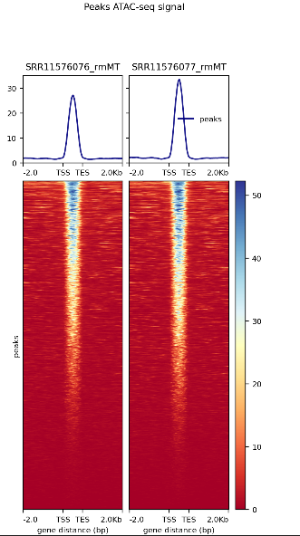

Is it allowed to turn this around? We go or it.

```bash
wget ftp://ftp.ncbi.nlm.nih.gov/geo/samples/GSM3744nnn/GSM3744545/suppl/GSM3744545%5FCD4%5Fip%2Ebw
```

```
--2020-12-18 11:42:22--  ftp://ftp.ncbi.nlm.nih.gov/geo/samples/GSM3744nnn/GSM3744545/suppl/GSM3744545%5FCD4%5Fip%2Ebw
           => ‘GSM3744545_CD4_ip.bw’
Resolving ftp.ncbi.nlm.nih.gov (ftp.ncbi.nlm.nih.gov)... 130.14.250.7, 2607:f220:41e:250::7, 2607:f220:41e:250::10, ...
Connecting to ftp.ncbi.nlm.nih.gov (ftp.ncbi.nlm.nih.gov)|130.14.250.7|:21... connected.
Logging in as anonymous ... Logged in!
==> SYST ... done.    ==> PWD ... done.
==> TYPE I ... done.  ==> CWD (1) /geo/samples/GSM3744nnn/GSM3744545/suppl ... done.
==> SIZE GSM3744545_CD4_ip.bw ... 77379038
==> PASV ... done.    ==> RETR GSM3744545_CD4_ip.bw ... done.
Length: 77379038 (74M) (unauthoritative)

GSM3744545_CD4_ip.b 100%[===================>]  73.79M  7.09MB/s    in 12s

2020-12-18 11:42:35 (6.25 MB/s) - ‘GSM3744545_CD4_ip.bw’ saved [77379038]
```

```bash
macs2 callpeak -B -t /mnt/storage/r0639760/jupyternotebooks/Assignment2/Mapping/bam/SRR11576077_rmMT.bam -n cre_pos_q --format BAMPE --keep-dup all -q 1e-7
```

```
INFO  @ Fri, 18 Dec 2020 12:25:09:
# Command line: callpeak -B -t /mnt/storage/r0639760/jupyternotebooks/Assignment2/Mapping/bam/SRR11576077_rmMT.bam -n cre_pos_q --format BAMPE --keep-dup all -q 1e-7
# ARGUMENTS LIST:
# name = cre_pos_q
# format = BAMPE
# ChIP-seq file = ['/mnt/storage/r0639760/jupyternotebooks/Assignment2/Mapping/bam/SRR11576077_rmMT.bam']
# control file = None
# effective genome size = 2.70e+09
# band width = 300
# model fold = [5, 50]
# qvalue cutoff = 1.00e-07
# The maximum gap between significant sites is assigned as the read length/tag size.
# The minimum length of peaks is assigned as the predicted fragment length "d".
# Larger dataset will be scaled towards smaller dataset.
# Range for calculating regional lambda is: 10000 bps
# Broad region calling is off
# Paired-End mode is on

INFO  @ Fri, 18 Dec 2020 12:25:09: #1 read fragment files...
INFO  @ Fri, 18 Dec 2020 12:25:09: #1 read treatment fragments...
INFO  @ Fri, 18 Dec 2020 12:25:12:  1000000
INFO  @ Fri, 18 Dec 2020 12:25:16:  2000000
INFO  @ Fri, 18 Dec 2020 12:25:20:  3000000
INFO  @ Fri, 18 Dec 2020 12:25:24:  4000000
INFO  @ Fri, 18 Dec 2020 12:25:29:  5000000
INFO  @ Fri, 18 Dec 2020 12:25:33:  6000000
INFO  @ Fri, 18 Dec 2020 12:25:37:  7000000
INFO  @ Fri, 18 Dec 2020 12:25:41:  8000000
INFO  @ Fri, 18 Dec 2020 12:25:46:  9000000
INFO  @ Fri, 18 Dec 2020 12:25:50:  10000000
INFO  @ Fri, 18 Dec 2020 12:25:54:  11000000
INFO  @ Fri, 18 Dec 2020 12:25:58:  12000000
INFO  @ Fri, 18 Dec 2020 12:26:02:  13000000
INFO  @ Fri, 18 Dec 2020 12:26:06:  14000000
INFO  @ Fri, 18 Dec 2020 12:26:11:  15000000
INFO  @ Fri, 18 Dec 2020 12:26:15:  16000000
INFO  @ Fri, 18 Dec 2020 12:26:19:  17000000
INFO  @ Fri, 18 Dec 2020 12:26:23:  18000000
INFO  @ Fri, 18 Dec 2020 12:26:28:  19000000
INFO  @ Fri, 18 Dec 2020 12:26:32:  20000000
INFO  @ Fri, 18 Dec 2020 12:26:36:  21000000
INFO  @ Fri, 18 Dec 2020 12:26:41:  22000000
INFO  @ Fri, 18 Dec 2020 12:26:45:  23000000
INFO  @ Fri, 18 Dec 2020 12:26:49:  24000000
INFO  @ Fri, 18 Dec 2020 12:27:08: #1 mean fragment size is determined as 128.6 bp from treatment
INFO  @ Fri, 18 Dec 2020 12:27:08: #1 fragment size = 128.6
INFO  @ Fri, 18 Dec 2020 12:27:08: #1  total fragments in treatment: 24413136
INFO  @ Fri, 18 Dec 2020 12:27:08: #1 finished!
INFO  @ Fri, 18 Dec 2020 12:27:08: #2 Build Peak Model...
INFO  @ Fri, 18 Dec 2020 12:27:08: #2 Skipped...
INFO  @ Fri, 18 Dec 2020 12:27:08: #3 Call peaks...
INFO  @ Fri, 18 Dec 2020 12:27:08: #3 Pre-compute pvalue-qvalue table...
INFO  @ Fri, 18 Dec 2020 12:27:52: #3 In the peak calling step, the following will be performed simultaneously:
INFO  @ Fri, 18 Dec 2020 12:27:52: #3   Write bedGraph files for treatment pileup (after scaling if necessary)... cre_pos_q_treat_pileup.bdg
INFO  @ Fri, 18 Dec 2020 12:27:52: #3   Write bedGraph files for control lambda (after scaling if necessary)... cre_pos_q_control_lambda.bdg
INFO  @ Fri, 18 Dec 2020 12:27:52: #3   Pileup will be based on sequencing depth in treatment.
INFO  @ Fri, 18 Dec 2020 12:27:52: #3 Call peaks for each chromosome...
INFO  @ Fri, 18 Dec 2020 12:58:43: #4 Write output xls file... cre_pos_q_peaks.xls
INFO  @ Fri, 18 Dec 2020 12:58:44: #4 Write peak in narrowPeak format file... cre_pos_q_peaks.narrowPeak
INFO  @ Fri, 18 Dec 2020 12:58:44: #4 Write summits bed file... cre_pos_q_summits.bed
INFO  @ Fri, 18 Dec 2020 12:58:44: Done!
```

```bash
macs2 callpeak -B -t /mnt/storage/r0639760/jupyternotebooks/Assignment2/Mapping/bam/SRR11576076_rmMT.bam -n cre_neg_q --format BAMPE --keep-dup all -q 1e-7
```

```
INFO  @ Fri, 18 Dec 2020 12:58:44:
# Command line: callpeak -B -t /mnt/storage/r0639760/jupyternotebooks/Assignment2/Mapping/bam/SRR11576076_rmMT.bam -n cre_neg_q --format BAMPE --keep-dup all -q 1e-7
# ARGUMENTS LIST:
# name = cre_neg_q
# format = BAMPE
# ChIP-seq file = ['/mnt/storage/r0639760/jupyternotebooks/Assignment2/Mapping/bam/SRR11576076_rmMT.bam']
# control file = None
# effective genome size = 2.70e+09
# band width = 300
# model fold = [5, 50]
# qvalue cutoff = 1.00e-07
# The maximum gap between significant sites is assigned as the read length/tag size.
# The minimum length of peaks is assigned as the predicted fragment length "d".
# Larger dataset will be scaled towards smaller dataset.
# Range for calculating regional lambda is: 10000 bps
# Broad region calling is off
# Paired-End mode is on

INFO  @ Fri, 18 Dec 2020 12:58:44: #1 read fragment files...
INFO  @ Fri, 18 Dec 2020 12:58:44: #1 read treatment fragments...
INFO  @ Fri, 18 Dec 2020 12:58:48:  1000000
INFO  @ Fri, 18 Dec 2020 12:58:52:  2000000
INFO  @ Fri, 18 Dec 2020 12:58:56:  3000000
INFO  @ Fri, 18 Dec 2020 12:59:01:  4000000
INFO  @ Fri, 18 Dec 2020 12:59:05:  5000000
INFO  @ Fri, 18 Dec 2020 12:59:10:  6000000
INFO  @ Fri, 18 Dec 2020 12:59:14:  7000000
INFO  @ Fri, 18 Dec 2020 12:59:19:  8000000
INFO  @ Fri, 18 Dec 2020 12:59:23:  9000000
INFO  @ Fri, 18 Dec 2020 12:59:28:  10000000
INFO  @ Fri, 18 Dec 2020 12:59:32:  11000000
INFO  @ Fri, 18 Dec 2020 12:59:36:  12000000
INFO  @ Fri, 18 Dec 2020 12:59:41:  13000000
INFO  @ Fri, 18 Dec 2020 12:59:45:  14000000
INFO  @ Fri, 18 Dec 2020 12:59:49:  15000000
INFO  @ Fri, 18 Dec 2020 12:59:54:  16000000
INFO  @ Fri, 18 Dec 2020 12:59:59:  17000000
INFO  @ Fri, 18 Dec 2020 13:00:03:  18000000
INFO  @ Fri, 18 Dec 2020 13:00:07:  19000000
INFO  @ Fri, 18 Dec 2020 13:00:12:  20000000
INFO  @ Fri, 18 Dec 2020 13:00:26: #1 mean fragment size is determined as 140.1 bp from treatment
INFO  @ Fri, 18 Dec 2020 13:00:26: #1 fragment size = 140.1
INFO  @ Fri, 18 Dec 2020 13:00:26: #1  total fragments in treatment: 20278648
INFO  @ Fri, 18 Dec 2020 13:00:26: #1 finished!
INFO  @ Fri, 18 Dec 2020 13:00:26: #2 Build Peak Model...
INFO  @ Fri, 18 Dec 2020 13:00:26: #2 Skipped...
INFO  @ Fri, 18 Dec 2020 13:00:26: #3 Call peaks...
INFO  @ Fri, 18 Dec 2020 13:00:26: #3 Pre-compute pvalue-qvalue table...
INFO  @ Fri, 18 Dec 2020 13:01:06: #3 In the peak calling step, the following will be performed simultaneously:
INFO  @ Fri, 18 Dec 2020 13:01:06: #3   Write bedGraph files for treatment pileup (after scaling if necessary)... cre_neg_q_treat_pileup.bdg
INFO  @ Fri, 18 Dec 2020 13:01:06: #3   Write bedGraph files for control lambda (after scaling if necessary)... cre_neg_q_control_lambda.bdg
INFO  @ Fri, 18 Dec 2020 13:01:06: #3   Pileup will be based on sequencing depth in treatment.
INFO  @ Fri, 18 Dec 2020 13:01:06: #3 Call peaks for each chromosome...
INFO  @ Fri, 18 Dec 2020 13:30:11: #4 Write output xls file... cre_neg_q_peaks.xls
INFO  @ Fri, 18 Dec 2020 13:30:11: #4 Write peak in narrowPeak format file... cre_neg_q_peaks.narrowPeak
INFO  @ Fri, 18 Dec 2020 13:30:11: #4 Write summits bed file... cre_neg_q_summits.bed
INFO  @ Fri, 18 Dec 2020 13:30:11: Done!
```

## Link Peaks to Genes

Use GREAT to link peaks to genes. GREAT also determines Gene Ontology enrichment of the linked (target) genes.

```bash
awk -F '.' '{print $1}' diff_pos_vs_neg_c3.0_cond1.bed > diff_pos_vs_neg_c3.0_cond1_int.bed
#great required int score values not floats
```

```bash
awk -F '.' '{print $1}' diff_pos_vs_neg_c3.0_cond2.bed > diff_pos_vs_neg_c3.0_cond2_int.bed
```

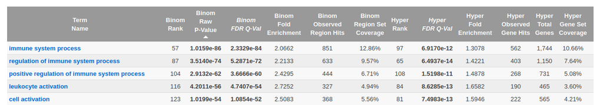

The peaks we called are near genes that are involved in immune processes for the KO sample. That is undoubtedly correct but quite superficial. Nevertheless it gives me more trust in the data analysis so far. Since these are the expected GO-terms (based on cond1).

The cond2 file did not lead to results, most likely due to the large number of peaks that were called more than in the KO condition. Thpok really seems to lead to a lot of open regions.

[figure not shown]

It would have been interesting to see which genes are more accesible in the presence of Thpok (so in the wt) compared to the KO to look at potential interaction partners but it is also interesting to look at the genes that seem to be more accesible in the KO. We will take this list from GREAT for the further analysis.

```bash
head 20201218-public-4.0.4-JV5qVZ-mm10-GOBiologicalProcess-GO_0002376-region.txt
```

```
# GREAT version 4.0.4	Species assembly: mm10	Association rule: Basal+extension: 5000 bp upstream, 1000 bp downstream, 100000 bp max extension, curated regulatory domains included
4930430F08Rik	diff_pos_vs_neg_cond1_677 (+42414)
Adam10	diff_pos_vs_neg_cond1_6325 (+16790)
Adar	diff_pos_vs_neg_cond1_4162 (-41754)
Add1	diff_pos_vs_neg_cond1_4775 (+13359)
Adgre1	diff_pos_vs_neg_cond1_2917 (+82729)
Adora3	diff_pos_vs_neg_cond1_4222 (+9795)
Agbl4	diff_pos_vs_neg_cond1_4529 (+53906)
Ahctf1	diff_pos_vs_neg_cond1_363 (-97658)
Akt1	diff_pos_vs_neg_cond1_1467 (-1029), diff_pos_vs_neg_cond1_1466 (-629)
```

```bash
cat 20201218-public-4.0.4-JV5qVZ-mm10-GOBiologicalProcess-GO_0002376-region.txt | cut -f 1 | grep -v '#' | wc -l
```

```
563
```

```bash
cat 20201218-public-4.0.4-JV5qVZ-mm10-GOBiologicalProcess-GO_0002376-region.txt | cut -f 1 | grep -v '#' | grep Runx3
```

```
Runx3
```

```bash
cat 20201218-public-4.0.4-JV5qVZ-mm10-GOBiologicalProcess-GO_0002376-region.txt | cut -f 1 | grep -v '#' > KOThpok-accesibleGenes-GREAT.txt
```

Thpok (Zbtb7b) is required to maintain the CD4+transcriptome but contrasting with this the expression of CD4+-signature genes in immature CD4+ SP thymocytes did not require Thpok (findings from RNA seq). ATAC-seq on CD4+SP thymocytes indicated that Thpok is dispensable for epigenomic opening of CD4-specific peaks, including at the Il2-Il21 locus. This challenges the idea thatThpok functions in thymocytes by promoting expression of Socs-family genes (Luckey et al., 2014). So the main finding in the paper was that there was not much change in the chromatin accessibility after KO of thpok for CD4+ lineage commitment, however, we see that there quite some genes related to immune system processesand leukocyte activation are more accessible after KO of Thpok. There is thus certainly still a lot to learn about the interaction of Thpok with other TFs, such as for example Runx3 for which some regions seem to be accessible in more cells when Thpok is knocked out, when looking at the GREAT results. However, RUNX3 is also described as interaction partner for Thpok (Zbtb7b), e.g. when using STRING:

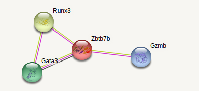

In this analysis we could not find that peaks in the wt cells were more associated with CfBF (which is known to form dimers with Runx) regions than KO. We suspect that this is due to a genome wide data set that was used. I should have used a CD4+ specific set of CfBf regions and then I would expect that there are more peaks in the wt associated with CfbF than in the KO. This suspicion is substantiated when looking at the Homer results, which show that Runx is both associated with peaks from the KO as well as the wt. But in the wt we find this association in CD4+ cells and in the KO in HPC7 cells.